# Elsevier 2022 SDG mapping

# General to all SDGs

## Introduction

The United Nations Sustainable Development Goals (SDGs) challenge the global community to build a world where no one is left behind.

Since 2018, Elsevier has generated SDG search queries to help researchers and institutions track and demonstrate progress toward the SDG targets. In the past 3 years, these queries, along with the university’s own data and evidence supporting progress and contributions to the particular SDG outside of research-based metrics, are used for the THE Impact Rankings.

## Method

For 2022, this SDG uses the exact same search query and ML algorithm as the Elsevier 2021 SDG mapping. [Full details of the 2021 methodology are available on Digital Commons Data.](https://elsevier.digitalcommonsdata.com/datasets/9sxdykm8s4/4)

# [SDG 10 - Reduce inequality within and among countries](https://sdgs.un.org/goals/goal10)

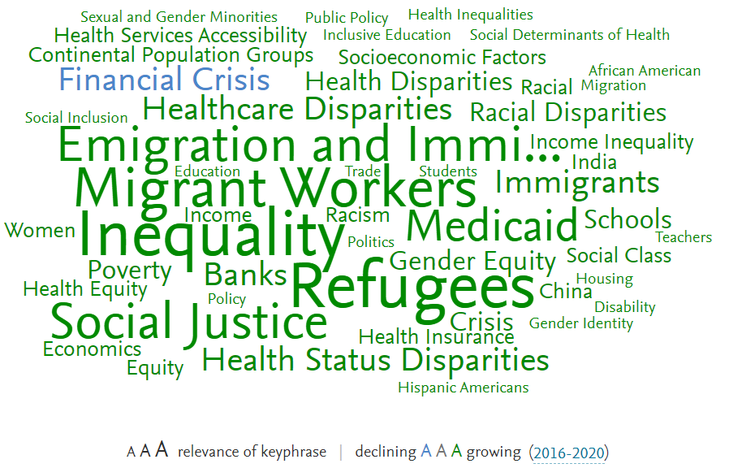

Explore this wordcloud plus the most active contributors on the [SciVal SDG site](https://scival.com/sdg)

## Query

Below is the full search query used for this SDG. We’ve broken it down by each query component. Use the + and – to concatenate the different bracket levels.

(

(

(

(

TITLE("regulat*") OR TITLE("law*") OR TITLE("legislation*")

)

AND

(

TITLE("financ*") OR TITLE("bank*")

)

)

OR

(

(

AUTHKEY("regulat*") OR AUTHKEY("law*") OR AUTHKEY("legislation*")

)

AND

(

AUTHKEY("financ*") OR AUTHKEY("bank*")

)

)

OR

(

TITLE-ABS

(

"immigrant labour"

)

OR TITLE-ABS

(

"immigrant labor"

)

)

OR

(

AUTHKEY

(

"immigrant labour"

)

OR AUTHKEY

(

"immigrant labor"

)

)

OR TITLE-ABS

(

"universal health coverage"

)

OR AUTHKEY

(

"universal health coverage"

)

OR

(

TITLE-ABS

(

"wage inequity"

)

OR TITLE-ABS

(

"wage inequities"

)

)

OR

(

AUTHKEY

(

"wage inequity"

)

OR AUTHKEY

(

"wage inequities"

)

)

OR TITLE-ABS

(

"emigration bill"

)

OR AUTHKEY

(

"emigration bill"

)

OR TITLE-ABS

(

"race segregation"

)

OR AUTHKEY

(

"race segregation"

)

OR

(

TITLE-ABS

(

"affordable house"

)

OR TITLE-ABS

(

"affordable houses"

)

)

OR

(

AUTHKEY

(

"affordable house"

)

OR AUTHKEY

(

"affordable houses"

)

)

OR TITLE-ABS

(

"earning* gap*"

)

OR AUTHKEY

(

"earning* gap*"

)

OR TITLE-ABS

(

"irregular immigration"

)

OR AUTHKEY

(

"irregular immigration"

)

OR

(

TITLE-ABS

(

"income disparity"

)

OR TITLE-ABS

(

"income disparities"

)

)

OR

(

AUTHKEY

(

"income disparity"

)

OR AUTHKEY

(

"income disparities"

)

)

OR

(

TITLE-ABS

(

"emigration regulation"

)

OR TITLE-ABS

(

"emigration regulations"

)

)

OR

(

AUTHKEY

(

"emigration regulation"

)

OR AUTHKEY

(

"emigration regulations"

)

)

OR TITLE-ABS

(

"class mobility"

)

OR AUTHKEY

(

"class mobility"

)

OR TITLE-ABS

(

"capital* market* law*"

)

OR AUTHKEY

(

"capital* market* law*"

)

OR

(

TITLE-ABS

(

"labour immigration"

)

OR TITLE-ABS

(

"labor immigration"

)

)

OR

(

AUTHKEY

(

"labour immigration"

)

OR AUTHKEY

(

"labor immigration"

)

)

OR

(

TITLE-ABS

(

"migration legislation"

)

OR TITLE-ABS

(

"migration legislations"

)

)

OR

(

AUTHKEY

(

"migration legislation"

)

OR AUTHKEY

(

"migration legislations"

)

)

OR TITLE-ABS

(

"financ* turmoil*"

)

OR AUTHKEY

(

"financ* turmoil*"

)

OR TITLE-ABS

(

"race discrimination"

)

OR AUTHKEY

(

"race discrimination"

)

OR

(

TITLE-ABS

(

"economic distribution"

)

OR TITLE-ABS

(

"economic distributions"

)

)

OR

(

AUTHKEY

(

"economic distribution"

)

OR AUTHKEY

(

"economic distributions"

)

)

OR

(

TITLE-ABS

(

"labour emigrant"

)

OR TITLE-ABS

(

"labour emigrants"

)

)

OR

(

AUTHKEY

(

"labour emigrant"

)

OR AUTHKEY

(

"labour emigrants"

)

)

OR

(

TITLE-ABS

(

"inequity in healthcare"

)

OR TITLE-ABS

(

"inequities in health"

)

)

OR

(

AUTHKEY

(

"inequity in healthcare"

)

OR AUTHKEY

(

"inequities in health"

)

)

OR TITLE-ABS

(

"reduce poverty"

)

OR AUTHKEY

(

"reduce poverty"

)

OR TITLE-ABS

(

"financing of terrorism"

)

OR AUTHKEY

(

"financing of terrorism"

)

OR TITLE-ABS

(

"wealth heterogeneity"

)

OR AUTHKEY

(

"wealth heterogeneity"

)

OR

(

TITLE-ABS

(

"socioeconomic inequity"

)

OR TITLE-ABS

(

"socioeconomic inequities"

)

)

OR

(

AUTHKEY

(

"socioeconomic inequity"

)

OR AUTHKEY

(

"socioeconomic inequities"

)

)

OR TITLE-ABS

(

"ethnic equality"

)

OR AUTHKEY

(

"ethnic equality"

)

OR TITLE-ABS

(

"illegal migration"

)

OR AUTHKEY

(

"illegal migration"

)

OR

(

TITLE-ABS

(

"undocumented student"

)

OR TITLE-ABS

(

"undocumented students"

)

)

OR

(

AUTHKEY

(

"undocumented student"

)

OR AUTHKEY

(

"undocumented students"

)

)

OR TITLE-ABS

(

"employment discrimination"

)

OR AUTHKEY

(

"employment discrimination"

)

OR TITLE-ABS

(

"residential segregation"

)

OR AUTHKEY

(

"residential segregation"

)

OR TITLE-ABS

(

"disability equality"

)

OR AUTHKEY

(

"disability equality"

)

OR TITLE-ABS

(

"age discrimination"

)

OR AUTHKEY

(

"age discrimination"

)

OR

(

TITLE-ABS

(

"antidiscrimination law"

)

OR TITLE-ABS

(

"antidiscrimination laws"

)

)

OR

(

AUTHKEY

(

"antidiscrimination law"

)

OR AUTHKEY

(

"antidiscrimination laws"

)

)

OR TITLE-ABS

(

"skilled immigration"

)

OR AUTHKEY

(

"skilled immigration"

)

OR

(

TITLE-ABS

(

"temporary migrant"

)

OR TITLE-ABS

(

"temporary migrants"

)

)

OR

(

AUTHKEY

(

"temporary migrant"

)

OR AUTHKEY

(

"temporary migrants"

)

)

OR TITLE-ABS

(

"economic justice"

)

OR AUTHKEY

(

"economic justice"

)

OR

(

TITLE-ABS

(

"bank* risk*"

)

AND NOT

(

TITLE-ABS("bankruptcy* risk*")

)

)

OR

(

AUTHKEY

(

"bank* risk*"

)

AND NOT

(

AUTHKEY("bankruptcy* risk*")

)

)

OR

(

TITLE-ABS

(

"diversity policy"

)

OR TITLE-ABS

(

"diversity policies"

)

)

OR

(

AUTHKEY

(

"diversity policy"

)

OR AUTHKEY

(

"diversity policies"

)

)

OR TITLE-ABS

(

"school desegregation"

)

OR AUTHKEY

(

"school desegregation"

)

OR TITLE-ABS

(

"humanitarian immigration"

)

OR AUTHKEY

(

"humanitarian immigration"

)

OR TITLE-ABS

(

"income redistribution"

)

OR AUTHKEY

(

"income redistribution"

)

OR TITLE-ABS

(

"poverty reduction"

)

OR AUTHKEY

(

"poverty reduction"

)

OR

(

TITLE-ABS

(

"legal migrant"

)

OR TITLE-ABS

(

"legal migrants"

)

)

OR

(

AUTHKEY

(

"legal migrant"

)

OR AUTHKEY

(

"legal migrants"

)

)

OR TITLE-ABS

(

"racial inclusion"

)

OR AUTHKEY

(

"racial inclusion"

)

OR

(

TITLE-ABS

(

"inclusive community"

)

OR TITLE-ABS

(

"inclusive communities"

)

)

OR

(

AUTHKEY

(

"inclusive community"

)

OR AUTHKEY

(

"inclusive communities"

)

)

OR

(

TITLE-ABS

(

"settlement agency"

)

OR TITLE-ABS

(

"settlement agencies"

)

)

OR

(

AUTHKEY

(

"settlement agency"

)

OR AUTHKEY

(

"settlement agencies"

)

)

OR TITLE-ABS

(

"migrant smuggling"

)

OR AUTHKEY

(

"migrant smuggling"

)

OR

(

TITLE-ABS

(

"migrant labour"

)

OR TITLE-ABS

(

"migrant labor"

)

)

OR

(

AUTHKEY

(

"migrant labour"

)

OR AUTHKEY

(

"migrant labor"

)

)

OR

(

TITLE-ABS

(

"pay inequality"

)

OR TITLE-ABS

(

"pay inequalities"

)

)

OR

(

AUTHKEY

(

"pay inequality"

)

OR AUTHKEY

(

"pay inequalities"

)

)

OR

(

TITLE-ABS

(

"pay differential"

)

OR TITLE-ABS

(

"pay differentials"

)

)

OR

(

AUTHKEY

(

"pay differential"

)

OR AUTHKEY

(

"pay differentials"

)

)

OR

(

TITLE-ABS

(

"gender inequality"

)

OR TITLE-ABS

(

"gender inequalities"

)

)

OR

(

AUTHKEY

(

"gender inequality"

)

OR AUTHKEY

(

"gender inequalities"

)

)

OR TITLE-ABS

(

"subsidized housing"

)

OR AUTHKEY

(

"subsidized housing"

)

OR TITLE-ABS

(

"social justice"

)

OR AUTHKEY

(

"social justice"

)

OR TITLE-ABS

(

"financ* market* regulat*"

)

OR AUTHKEY

(

"financ* market* regulat*"

)

OR

(

TITLE-ABS

(

"wage distribution"

)

OR TITLE-ABS

(

"wage distributions"

)

)

OR

(

AUTHKEY

(

"wage distribution"

)

OR AUTHKEY

(

"wage distributions"

)

)

OR

(

TITLE-ABS

(

"immigrant worker"

)

OR TITLE-ABS

(

"immigrant workers"

)

)

OR

(

AUTHKEY

(

"immigrant worker"

)

OR AUTHKEY

(

"immigrant workers"

)

)

OR TITLE-ABS

(

"unauthorized immigration"

)

OR AUTHKEY

(

"unauthorized immigration"

)

OR TITLE-ABS

(

"hiring discrimination"

)

OR AUTHKEY

(

"hiring discrimination"

)

OR TITLE-ABS

(

"political inclusion"

)

OR AUTHKEY

(

"political inclusion"

)

OR TITLE-ABS

(

"social housing"

)

OR AUTHKEY

(

"social housing"

)

OR

(

TITLE-ABS

(

"refugee claimant"

)

OR TITLE-ABS

(

"refugee claimants"

)

)

OR

(

AUTHKEY

(

"refugee claimant"

)

OR AUTHKEY

(

"refugee claimants"

)

)

OR TITLE-ABS

(

"workplace discrimination"

)

OR AUTHKEY

(

"workplace discrimination"

)

OR TITLE-ABS

(

"asylum process"

)

OR AUTHKEY

(

"asylum process"

)

OR TITLE-ABS

(

"gender wage discrimination"

)

OR AUTHKEY

(

"gender wage discrimination"

)

OR TITLE-ABS

(

"governance of immigration"

)

OR AUTHKEY

(

"governance of immigration"

)

OR TITLE-ABS

(

"estate taxation"

)

OR AUTHKEY

(

"estate taxation"

)

OR

(

TITLE-ABS

(

"equality policy"

)

OR TITLE-ABS

(

"equality policies"

)

)

OR

(

AUTHKEY

(

"equality policy"

)

OR AUTHKEY

(

"equality policies"

)

)

OR TITLE-ABS

(

"integration of emigrants"

)

OR AUTHKEY

(

"integration of emigrants"

)

OR

(

TITLE-ABS

(

"inequality of wealth"

)

OR TITLE-ABS

(

"inequalities of wealth"

)

)

OR

(

AUTHKEY

(

"inequality of wealth"

)

OR AUTHKEY

(

"inequalities of wealth"

)

)

OR

(

TITLE-ABS

(

"disparity in health"

)

OR TITLE-ABS

(

"disparities in health"

)

)

OR

(

AUTHKEY

(

"disparity in health"

)

OR AUTHKEY

(

"disparities in health"

)

)

OR TITLE-ABS

(

"discrimination in healthcare"

)

OR AUTHKEY

(

"discrimination in healthcare"

)

OR TITLE-ABS

(

"politics of immigration"

)

OR AUTHKEY

(

"politics of immigration"

)

OR

(

(

TITLE-ABS("low-cost house") OR TITLE-ABS("low-cost houses")

)

OR

(

TITLE-ABS("lowcost house") OR TITLE-ABS("lowcost houses")

)

)

OR

(

(

AUTHKEY("low-cost house") OR AUTHKEY("low-cost houses")

)

OR

(

AUTHKEY("lowcost house") OR AUTHKEY("lowcost houses")

)

)

OR TITLE-ABS

(

"wealth mobility"

)

OR AUTHKEY

(

"wealth mobility"

)

OR

(

TITLE-ABS

(

"bank* legislation*"

)

AND NOT

(

TITLE-ABS("bankruptcy* legislation*")

)

)

OR

(

AUTHKEY

(

"bank* legislation*"

)

AND NOT

(

AUTHKEY("bankruptcy* legislation*")

)

)

OR TITLE-ABS

(

"educational segregation"

)

OR AUTHKEY

(

"educational segregation"

)

OR TITLE-ABS

(

"people seeking asylum"

)

OR AUTHKEY

(

"people seeking asylum"

)

OR

(

TITLE-ABS

(

"health inequality"

)

OR TITLE-ABS

(

"health inequalities"

)

)

OR

(

AUTHKEY

(

"health inequality"

)

OR AUTHKEY

(

"health inequalities"

)

)

OR TITLE-ABS

(

"equal employment"

)

OR AUTHKEY

(

"equal employment"

)

OR TITLE-ABS

(

"temporary emigration"

)

OR AUTHKEY

(

"temporary emigration"

)

OR TITLE-ABS

(

"alleviating poverty"

)

OR AUTHKEY

(

"alleviating poverty"

)

OR

(

TITLE-ABS

(

"socioeconomic disparity"

)

OR TITLE-ABS

(

"socioeconomic disparities"

)

)

OR

(

AUTHKEY

(

"socioeconomic disparity"

)

OR AUTHKEY

(

"socioeconomic disparities"

)

)

OR TITLE-ABS

(

"economic mobility"

)

OR AUTHKEY

(

"economic mobility"

)

OR TITLE-ABS

(

"ethnic justice"

)

OR AUTHKEY

(

"ethnic justice"

)

OR

(

TITLE-ABS

(

"redistributive monetary policy"

)

OR TITLE-ABS

(

"redistributive monetary policies"

)

)

OR

(

AUTHKEY

(

"redistributive monetary policy"

)

OR AUTHKEY

(

"redistributive monetary policies"

)

)

OR TITLE-ABS

(

"socioeconomic segregation"

)

OR AUTHKEY

(

"socioeconomic segregation"

)

OR

(

TITLE-ABS

(

"immigration restriction"

)

OR TITLE-ABS

(

"immigration restrictions"

)

)

OR

(

AUTHKEY

(

"immigration restriction"

)

OR AUTHKEY

(

"immigration restrictions"

)

)

OR

(

TITLE-ABS

(

"economic inequality"

)

OR TITLE-ABS

(

"economic inequalities"

)

)

OR

(

AUTHKEY

(

"economic inequality"

)

OR AUTHKEY

(

"economic inequalities"

)

)

OR TITLE-ABS

(

"inclusive transport"

)

OR AUTHKEY

(

"inclusive transport"

)

OR

(

TITLE-ABS

(

"emigrant rights"

)

OR TITLE-ABS

(

"emigrants rights"

)

)

OR

(

AUTHKEY

(

"emigrant rights"

)

OR AUTHKEY

(

"emigrants rights"

)

)

OR

(

TITLE-ABS

(

"salary differential"

)

OR TITLE-ABS

(

"salary differentials"

)

)

OR

(

AUTHKEY

(

"salary differential"

)

OR AUTHKEY

(

"salary differentials"

)

)

OR TITLE-ABS

(

"emigration selection"

)

OR AUTHKEY

(

"emigration selection"

)

OR

(

TITLE-ABS

(

"wage differential"

)

OR TITLE-ABS

(

"wage differentials"

)

)

OR

(

AUTHKEY

(

"wage differential"

)

OR AUTHKEY

(

"wage differentials"

)

)

OR

(

TITLE-ABS

(

"inclusive society"

)

OR TITLE-ABS

(

"inclusive societies"

)

)

OR

(

AUTHKEY

(

"inclusive society"

)

OR AUTHKEY

(

"inclusive societies"

)

)

OR

(

TITLE-ABS

(

"child development account"

)

OR TITLE-ABS

(

"child development accounts"

)

)

OR

(

AUTHKEY

(

"child development account"

)

OR AUTHKEY

(

"child development accounts"

)

)

OR

(

TITLE-ABS

(

"race inequality"

)

OR TITLE-ABS

(

"race inequalities"

)

)

OR

(

AUTHKEY

(

"race inequality"

)

OR AUTHKEY

(

"race inequalities"

)

)

OR TITLE-ABS

(

"financ* shock*"

)

OR AUTHKEY

(

"financ* shock*"

)

OR TITLE-ABS

(

"subprime crisis"

)

OR AUTHKEY

(

"subprime crisis"

)

OR

(

TITLE-ABS

(

"labor emigrant"

)

OR TITLE-ABS

(

"labor emigrants"

)

)

OR

(

AUTHKEY

(

"labor emigrant"

)

OR AUTHKEY

(

"labor emigrants"

)

)

OR

(

TITLE-ABS

(

"salary gap"

)

OR TITLE-ABS

(

"salary gaps"

)

)

OR

(

AUTHKEY

(

"salary gap"

)

OR AUTHKEY

(

"salary gaps"

)

)

OR TITLE-ABS

(

"housing segregation"

)

OR AUTHKEY

(

"housing segregation"

)

OR

(

TITLE-ABS

(

"migration flow"

)

OR TITLE-ABS

(

"migration flows"

)

)

OR

(

AUTHKEY

(

"migration flow"

)

OR AUTHKEY

(

"migration flows"

)

)

OR

(

TITLE-ABS

(

"Basel* regulation*"

)

AND NOT

(

TITLE-ABS("baseline* regulation*")

)

)

OR

(

AUTHKEY

(

"Basel* regulation*"

)

AND NOT

(

AUTHKEY("baseline* regulation*")

)

)

OR

(

TITLE-ABS

(

"desegregation policy"

)

OR TITLE-ABS

(

"desegregation policies"

)

)

OR

(

AUTHKEY

(

"desegregation policy"

)

OR AUTHKEY

(

"desegregation policies"

)

)

OR

(

TITLE-ABS

(

"income inequality"

)

OR TITLE-ABS

(

"income inequalities"

)

)

OR

(

AUTHKEY

(

"income inequality"

)

OR AUTHKEY

(

"income inequalities"

)

)

OR TITLE-ABS

(

"earning* differential*"

)

OR AUTHKEY

(

"earning* differential*"

)

OR TITLE-ABS

(

"regulatory capital"

)

OR AUTHKEY

(

"regulatory capital"

)

OR

(

TITLE-ABS

(

"minimum wage"

)

OR TITLE-ABS

(

"minimum wages"

)

)

OR

(

AUTHKEY

(

"minimum wage"

)

OR AUTHKEY

(

"minimum wages"

)

)

OR

(

TITLE-ABS

(

"skilled emigrant"

)

OR TITLE-ABS

(

"skilled emigrants"

)

)

OR

(

AUTHKEY

(

"skilled emigrant"

)

OR AUTHKEY

(

"skilled emigrants"

)

)

OR

(

TITLE-ABS

(

"migrant rights"

)

OR TITLE-ABS

(

"migrants rights"

)

)

OR

(

AUTHKEY

(

"migrant rights"

)

OR AUTHKEY

(

"migrants rights"

)

)

OR

(

TITLE-ABS

(

"immigrant rights"

)

OR TITLE-ABS

(

"immigrants rights"

)

)

OR

(

AUTHKEY

(

"immigrant rights"

)

OR AUTHKEY

(

"immigrants rights"

)

)

OR TITLE-ABS

(

"living wage"

)

OR AUTHKEY

(

"living wage"

)

OR TITLE-ABS

(

"social stratification"

)

OR AUTHKEY

(

"social stratification"

)

OR

(

TITLE-ABS

(

"inclusive city"

)

OR TITLE-ABS

(

"inclusive cities"

)

)

OR

(

AUTHKEY

(

"inclusive city"

)

OR AUTHKEY

(

"inclusive cities"

)

)

OR TITLE-ABS

(

"supervisory convergence"

)

OR AUTHKEY

(

"supervisory convergence"

)

OR

(

TITLE-ABS

(

"irregular emigrant"

)

OR TITLE-ABS

(

"irregular emigrants"

)

)

OR

(

AUTHKEY

(

"irregular emigrant"

)

OR AUTHKEY

(

"irregular emigrants"

)

)

OR

(

TITLE-ABS

(

"gender disparity"

)

OR TITLE-ABS

(

"gender disparities"

)

)

OR

(

AUTHKEY

(

"gender disparity"

)

OR AUTHKEY

(

"gender disparities"

)

)

OR

(

TITLE-ABS

(

"undocumented child"

)

OR TITLE-ABS

(

"undocumented children"

)

)

OR

(

AUTHKEY

(

"undocumented child"

)

OR AUTHKEY

(

"undocumented children"

)

)

OR

(

TITLE-ABS

(

"healthcare disparity"

)

OR TITLE-ABS

(

"healthcare disparities"

)

)

OR

(

AUTHKEY

(

"healthcare disparity"

)

OR AUTHKEY

(

"healthcare disparities"

)

)

OR TITLE-ABS

(

"wage growth"

)

OR AUTHKEY

(

"wage growth"

)

OR

(

TITLE-ABS

(

"immigration control"

)

OR TITLE-ABS

(

"immigration controls"

)

)

OR

(

AUTHKEY

(

"immigration control"

)

OR AUTHKEY

(

"immigration controls"

)

)

OR

(

TITLE-ABS

(

"refugee policy"

)

OR TITLE-ABS

(

"refugee policies"

)

)

OR

(

AUTHKEY

(

"refugee policy"

)

OR AUTHKEY

(

"refugee policies"

)

)

OR TITLE-ABS

(

"racial discrimination"

)

OR AUTHKEY

(

"racial discrimination"

)

OR TITLE-ABS

(

"inclusive learning"

)

OR AUTHKEY

(

"inclusive learning"

)

OR TITLE-ABS

(

"education inclusion"

)

OR AUTHKEY

(

"education inclusion"

)

OR TITLE-ABS

(

"financ* cris*"

)

OR AUTHKEY

(

"financ* cris*"

)

OR TITLE-ABS

(

"poverty alleviation"

)

OR AUTHKEY

(

"poverty alleviation"

)

OR TITLE-ABS

(

"earning* mobilit*"

)

OR AUTHKEY

(

"earning* mobilit*"

)

OR TITLE-ABS

(

"pay equality"

)

OR AUTHKEY

(

"pay equality"

)

OR

(

TITLE-ABS

(

"discrimination law"

)

OR TITLE-ABS

(

"discrimination laws"

)

)

OR

(

AUTHKEY

(

"discrimination law"

)

OR AUTHKEY

(

"discrimination laws"

)

)

OR TITLE-ABS

(

"workforce diversity"

)

OR AUTHKEY

(

"workforce diversity"

)

OR TITLE-ABS

(

"educational inclusion"

)

OR AUTHKEY

(

"educational inclusion"

)

OR

(

TITLE-ABS

(

"discrimination policy"

)

OR TITLE-ABS

(

"discrimination policies"

)

)

OR

(

AUTHKEY

(

"discrimination policy"

)

OR AUTHKEY

(

"discrimination policies"

)

)

OR TITLE-ABS

(

"social equity"

)

OR AUTHKEY

(

"social equity"

)

OR

(

TITLE-ABS

(

"estate tax"

)

OR TITLE-ABS

(

"estate taxes"

)

)

OR

(

AUTHKEY

(

"estate tax"

)

OR AUTHKEY

(

"estate taxes"

)

)

OR TITLE-ABS

(

"macroprudential* supervis*"

)

OR AUTHKEY

(

"macroprudential* supervis*"

)

OR TITLE-ABS

(

"inheritance taxation"

)

OR AUTHKEY

(

"inheritance taxation"

)

OR TITLE-ABS

(

"medicaid"

)

OR AUTHKEY

(

"medicaid"

)

OR TITLE-ABS

(

"gender mainstreaming"

)

OR AUTHKEY

(

"gender mainstreaming"

)

OR

(

TITLE-ABS

(

"refugee law"

)

OR TITLE-ABS

(

"refugee laws"

)

)

OR

(

AUTHKEY

(

"refugee law"

)

OR AUTHKEY

(

"refugee laws"

)

)

OR TITLE-ABS

(

"reduction of poverty"

)

OR AUTHKEY

(

"reduction of poverty"

)

OR TITLE-ABS

(

"governance of emigration"

)

OR AUTHKEY

(

"governance of emigration"

)

OR TITLE-ABS

(

"distribution of income"

)

OR AUTHKEY

(

"distribution of income"

)

OR

(

TITLE-ABS

(

"bank* law*"

)

AND NOT

(

TITLE-ABS("bankruptcy* law*")

)

)

OR

(

AUTHKEY

(

"bank* law*"

)

AND NOT

(

AUTHKEY("bankruptcy* law*")

)

)

OR TITLE-ABS

(

"politics of emigration"

)

OR AUTHKEY

(

"politics of emigration"

)

OR TITLE-ABS

(

"immigration enforcement"

)

OR AUTHKEY

(

"immigration enforcement"

)

OR

(

TITLE-ABS

(

"antidiscrimination policy"

)

OR TITLE-ABS

(

"antidiscrimination policies"

)

)

OR

(

AUTHKEY

(

"antidiscrimination policy"

)

OR AUTHKEY

(

"antidiscrimination policies"

)

)

OR TITLE-ABS

(

"racial stratification"

)

OR AUTHKEY

(

"racial stratification"

)

OR TITLE-ABS

(

"pay parity"

)

OR AUTHKEY

(

"pay parity"

)

OR TITLE-ABS

(

"inclusionary housing"

)

OR AUTHKEY

(

"inclusionary housing"

)

OR

(

TITLE-ABS

(

"undocumented labour"

)

OR TITLE-ABS

(

"undocumented labor"

)

)

OR

(

AUTHKEY

(

"undocumented labour"

)

OR AUTHKEY

(

"undocumented labor"

)

)

OR

(

TITLE-ABS

(

"socioeconomic differential"

)

OR TITLE-ABS

(

"socioeconomic differentials"

)

)

OR

(

AUTHKEY

(

"socioeconomic differential"

)

OR AUTHKEY

(

"socioeconomic differentials"

)

)

OR TITLE-ABS

(

"bank* supervis*"

)

OR AUTHKEY

(

"bank* supervis*"

)

OR

(

TITLE-ABS

(

"equal employment opportunity"

)

OR TITLE-ABS

(

"equal employment opportunities"

)

)

OR

(

AUTHKEY

(

"equal employment opportunity"

)

OR AUTHKEY

(

"equal employment opportunities"

)

)

OR TITLE-ABS

(

"economic migration"

)

OR AUTHKEY

(

"economic migration"

)

OR TITLE-ABS

(

"Wall Street reform"

)

OR AUTHKEY

(

"Wall Street reform"

)

OR TITLE-ABS

(

"alleviate poverty"

)

OR AUTHKEY

(

"alleviate poverty"

)

OR

(

TITLE-ABS

(

"health care inequity"

)

OR TITLE-ABS

(

"health care inequities"

)

)

OR

(

AUTHKEY

(

"health care inequity"

)

OR AUTHKEY

(

"health care inequities"

)

)

OR TITLE-ABS

(

"socioeconomic mobility"

)

OR AUTHKEY

(

"socioeconomic mobility"

)

OR TITLE-ABS

(

"return migration"

)

OR AUTHKEY

(

"return migration"

)

OR TITLE-ABS

(

"forced emigration"

)

OR AUTHKEY

(

"forced emigration"

)

OR

(

TITLE-ABS

(

"emigration rule"

)

OR TITLE-ABS

(

"emigration rules"

)

)

OR

(

AUTHKEY

(

"emigration rule"

)

OR AUTHKEY

(

"emigration rules"

)

)

OR TITLE-ABS

(

"skilled migration"

)

OR AUTHKEY

(

"skilled migration"

)

OR

(

TITLE-ABS

(

"ethnic inequity"

)

OR TITLE-ABS

(

"ethnic inequities"

)

)

OR

(

AUTHKEY

(

"ethnic inequity"

)

OR AUTHKEY

(

"ethnic inequities"

)

)

OR TITLE-ABS

(

"political emigration"

)

OR AUTHKEY

(

"political emigration"

)

OR TITLE-ABS

(

"terrorism financing"

)

OR AUTHKEY

(

"terrorism financing"

)

OR

(

TITLE-ABS

(

"migration policy"

)

OR TITLE-ABS

(

"migration policies"

)

)

OR

(

AUTHKEY

(

"migration policy"

)

OR AUTHKEY

(

"migration policies"

)

)

OR

(

TITLE-ABS

(

"disability policy"

)

OR TITLE-ABS

(

"disability policies"

)

)

OR

(

AUTHKEY

(

"disability policy"

)

OR AUTHKEY

(

"disability policies"

)

)

OR TITLE-ABS

(

"stratification of society"

)

OR AUTHKEY

(

"stratification of society"

)

OR

(

TITLE-ABS

(

"illegal alien"

)

OR TITLE-ABS

(

"illegal aliens"

)

)

OR

(

AUTHKEY

(

"illegal alien"

)

OR AUTHKEY

(

"illegal aliens"

)

)

OR TITLE-ABS

(

"upward mobility"

)

OR AUTHKEY

(

"upward mobility"

)

OR TITLE-ABS

(

"economic emigration"

)

OR AUTHKEY

(

"economic emigration"

)

OR

(

TITLE-ABS

(

"securities* law*"

)

AND NOT

(

TITLE-ABS("securities* lawsuit*")

)

)

OR

(

AUTHKEY

(

"securities* law*"

)

AND NOT

(

AUTHKEY("securities* lawsuit*")

)

)

OR TITLE-ABS

(

"salary equity"

)

OR AUTHKEY

(

"salary equity"

)

OR TITLE-ABS

(

"Financial Services Authority"

)

OR AUTHKEY

(

"Financial Services Authority"

)

OR TITLE-ABS

(

"financ* service* regulat*"

)

OR AUTHKEY

(

"financ* service* regulat*"

)

OR

(

TITLE-ABS

(

"migratory control"

)

OR TITLE-ABS

(

"migratory controls"

)

)

OR

(

AUTHKEY

(

"migratory control"

)

OR AUTHKEY

(

"migratory controls"

)

)

OR

(

TITLE-ABS

(

"emigration legislation"

)

OR TITLE-ABS

(

"emigration legislations"

)

)

OR

(

AUTHKEY

(

"emigration legislation"

)

OR AUTHKEY

(

"emigration legislations"

)

)

OR

(

TITLE-ABS

(

"labour migration"

)

OR TITLE-ABS

(

"labor migration"

)

)

OR

(

AUTHKEY

(

"labour migration"

)

OR AUTHKEY

(

"labor migration"

)

)

OR TITLE-ABS

(

"irregular migration"

)

OR AUTHKEY

(

"irregular migration"

)

OR

(

TITLE-ABS

(

"affordable rental"

)

OR TITLE-ABS

(

"affordable rentals"

)

)

OR

(

AUTHKEY

(

"affordable rental"

)

OR AUTHKEY

(

"affordable rentals"

)

)

OR

(

TITLE-ABS

(

"inclusive preschool"

)

OR TITLE-ABS

(

"inclusive preschools"

)

)

OR

(

AUTHKEY

(

"inclusive preschool"

)

OR AUTHKEY

(

"inclusive preschools"

)

)

OR

(

TITLE-ABS

(

"migration control"

)

OR TITLE-ABS

(

"migration controls"

)

)

OR

(

AUTHKEY

(

"migration control"

)

OR AUTHKEY

(

"migration controls"

)

)

OR

(

TITLE-ABS

(

"income gap"

)

OR TITLE-ABS

(

"income gaps"

)

)

OR

(

AUTHKEY

(

"income gap"

)

OR AUTHKEY

(

"income gaps"

)

)

OR TITLE-ABS

(

"deposit insurance"

)

OR AUTHKEY

(

"deposit insurance"

)

OR TITLE-ABS

(

"international immigration"

)

OR AUTHKEY

(

"international immigration"

)

OR

(

TITLE-ABS

(

"racial inequity"

)

OR TITLE-ABS

(

"racial inequities"

)

)

OR

(

AUTHKEY

(

"racial inequity"

)

OR AUTHKEY

(

"racial inequities"

)

)

OR

(

TITLE-ABS

(

"foreign worker"

)

OR TITLE-ABS

(

"foreign workers"

)

)

OR

(

AUTHKEY

(

"foreign worker"

)

OR AUTHKEY

(

"foreign workers"

)

)

OR

(

TITLE-ABS

(

"immigrant policy"

)

OR TITLE-ABS

(

"immigrant policies"

)

)

OR

(

AUTHKEY

(

"immigrant policy"

)

OR AUTHKEY

(

"immigrant policies"

)

)

OR

(

TITLE-ABS

(

"progressive income tax"

)

OR TITLE-ABS

(

"progressive income taxes"

)

)

OR

(

AUTHKEY

(

"progressive income tax"

)

OR AUTHKEY

(

"progressive income taxes"

)

)

OR TITLE-ABS

(

"fair housing"

)

OR AUTHKEY

(

"fair housing"

)

OR TITLE-ABS

(

"equal pay"

)

OR AUTHKEY

(

"equal pay"

)

OR TITLE-ABS

(

"supervision* of* financ*"

)

OR AUTHKEY

(

"supervision* of* financ*"

)

OR

(

TITLE-ABS

(

"regulation* of* bank*"

)

AND NOT

(

TITLE-ABS("regulation of bankruptcy")

)

)

OR

(

AUTHKEY

(

"regulation* of* bank*"

)

AND NOT

(

AUTHKEY("regulation of bankruptcy")

)

)

OR TITLE-ABS

(

"unauthorized migration"

)

OR AUTHKEY

(

"unauthorized migration"

)

OR TITLE-ABS

(

"racial desegregation"

)

OR AUTHKEY

(

"racial desegregation"

)

OR

(

TITLE-ABS

(

"housing inequality"

)

OR TITLE-ABS

(

"housing inequalities"

)

)

OR

(

AUTHKEY

(

"housing inequality"

)

OR AUTHKEY

(

"housing inequalities"

)

)

OR TITLE-ABS

(

"education equity"

)

OR AUTHKEY

(

"education equity"

)

OR

(

TITLE-ABS

(

"wage gap"

)

OR TITLE-ABS

(

"wage gaps"

)

)

OR

(

AUTHKEY

(

"wage gap"

)

OR AUTHKEY

(

"wage gaps"

)

)

OR TITLE-ABS

(

"immigration bill"

)

OR AUTHKEY

(

"immigration bill"

)

OR TITLE-ABS

(

"politics of migration"

)

OR AUTHKEY

(

"politics of migration"

)

OR TITLE-ABS

(

"earning* inequit*"

)

OR AUTHKEY

(

"earning* inequit*"

)

OR TITLE-ABS

(

"workplace inclusion"

)

OR AUTHKEY

(

"workplace inclusion"

)

OR

(

TITLE-ABS

(

"pay disparity"

)

OR TITLE-ABS

(

"pay disparities"

)

)

OR

(

AUTHKEY

(

"pay disparity"

)

OR AUTHKEY

(

"pay disparities"

)

)

OR TITLE-ABS

(

"inclusive education"

)

OR AUTHKEY

(

"inclusive education"

)

OR TITLE-ABS

(

"discrimination in the workplace"

)

OR AUTHKEY

(

"discrimination in the workplace"

)

OR

(

(

TITLE-ABS("income-related inequality") OR TITLE-ABS("income-related inequalities")

)

OR

(

TITLE-ABS("incomerelated inequality") OR TITLE-ABS("incomerelated inequalities")

)

)

OR

(

(

AUTHKEY("income-related inequality") OR AUTHKEY("income-related inequalities")

)

OR

(

AUTHKEY("incomerelated inequality") OR AUTHKEY("incomerelated inequalities")

)

)

OR TITLE-ABS

(

"capital* regulat*"

)

OR AUTHKEY

(

"capital* regulat*"

)

OR TITLE-ABS

(

"management of migration"

)

OR AUTHKEY

(

"management of migration"

)

OR

(

TITLE-ABS

(

"inequity in health"

)

OR TITLE-ABS

(

"inequities in health"

)

)

OR

(

AUTHKEY

(

"inequity in health"

)

OR AUTHKEY

(

"inequities in health"

)

)

OR TITLE-ABS

(

"social inclusiveness"

)

OR AUTHKEY

(

"social inclusiveness"

)

OR

(

TITLE-ABS

(

"immigration law"

)

OR TITLE-ABS

(

"immigration laws"

)

)

OR

(

AUTHKEY

(

"immigration law"

)

OR AUTHKEY

(

"immigration laws"

)

)

OR TITLE-ABS

(

"asylum seeking"

)

OR AUTHKEY

(

"asylum seeking"

)

OR TITLE-ABS

(

"transnational emigration"

)

OR AUTHKEY

(

"transnational emigration"

)

OR

(

TITLE-ABS

(

"low-income housing"

)

OR TITLE-ABS

(

"lowincome housing"

)

)

OR

(

AUTHKEY

(

"low-income housing"

)

OR AUTHKEY

(

"lowincome housing"

)

)

OR TITLE-ABS

(

"integration of migrants"

)

OR AUTHKEY

(

"integration of migrants"

)

OR TITLE-ABS

(

"microprudential* supervis*"

)

OR AUTHKEY

(

"microprudential* supervis*"

)

OR

(

TITLE-ABS

(

"policy of inclusion"

)

OR TITLE-ABS

(

"policies of inclusion"

)

)

OR

(

AUTHKEY

(

"policy of inclusion"

)

OR AUTHKEY

(

"policies of inclusion"

)

)

OR TITLE-ABS

(

"immigration selection"

)

OR AUTHKEY

(

"immigration selection"

)

OR

(

TITLE-ABS

(

"asylum applicant"

)

OR TITLE-ABS

(

"asylum applicants"

)

)

OR

(

AUTHKEY

(

"asylum applicant"

)

OR AUTHKEY

(

"asylum applicants"

)

)

OR TITLE-ABS

(

"undocumented emigration"

)

OR AUTHKEY

(

"undocumented emigration"

)

OR

(

TITLE-ABS

(

"wealth tax"

)

OR TITLE-ABS

(

"wealth taxes"

)

)

OR

(

AUTHKEY

(

"wealth tax"

)

OR AUTHKEY

(

"wealth taxes"

)

)

OR TITLE-ABS

(

"distributed capitalism"

)

OR AUTHKEY

(

"distributed capitalism"

)

OR

(

TITLE-ABS

(

"economic refugee"

)

OR TITLE-ABS

(

"economic refugees"

)

)

OR

(

AUTHKEY

(

"economic refugee"

)

OR AUTHKEY

(

"economic refugees"

)

)

OR TITLE-ABS

(

"global emigration"

)

OR AUTHKEY

(

"global emigration"

)

OR TITLE-ABS

(

"refugee determination"

)

OR AUTHKEY

(

"refugee determination"

)

OR

(

TITLE-ABS

(

"wealth disparity"

)

OR TITLE-ABS

(

"wealth disparities"

)

)

OR

(

AUTHKEY

(

"wealth disparity"

)

OR AUTHKEY

(

"wealth disparities"

)

)

OR

(

TITLE-ABS

(

"skilled immigrant"

)

OR TITLE-ABS

(

"skilled immigrants"

)

)

OR

(

AUTHKEY

(

"skilled immigrant"

)

OR AUTHKEY

(

"skilled immigrants"

)

)

OR TITLE-ABS

(

"americans with disabilities act"

)

OR AUTHKEY

(

"americans with disabilities act"

)

OR TITLE-ABS

(

"ethnic stratification"

)

OR AUTHKEY

(

"ethnic stratification"

)

OR

(

TITLE-ABS

(

"socioeconomic inequality"

)

OR TITLE-ABS

(

"socioeconomic inequalities"

)

)

OR

(

AUTHKEY

(

"socioeconomic inequality"

)

OR AUTHKEY

(

"socioeconomic inequalities"

)

)

OR

(

TITLE-ABS

(

"forced migrant"

)

OR TITLE-ABS

(

"forced migrants"

)

)

OR

(

AUTHKEY

(

"forced migrant"

)

OR AUTHKEY

(

"forced migrants"

)

)

OR TITLE-ABS

(

"Basel I"

)

OR AUTHKEY

(

"Basel I"

)

OR

(

TITLE-ABS

(

"employee with disability"

)

OR TITLE-ABS

(

"employee with disabilities"

)

OR TITLE-ABS

(

"employees with disability"

)

OR TITLE-ABS

(

"employees with disabilities"

)

)

OR

(

AUTHKEY

(

"employee with disability"

)

OR AUTHKEY

(

"employee with disabilities"

)

OR AUTHKEY

(

"employees with disability"

)

OR AUTHKEY

(

"employees with disabilities"

)

)

OR

(

TITLE-ABS

(

"bank* regulat*"

)

AND NOT

(

TITLE-ABS("bankruptcy* regulat*")

)

)

OR

(

AUTHKEY

(

"bank* regulat*"

)

AND NOT

(

AUTHKEY("bankruptcy* regulat*")

)

)

OR TITLE-ABS

(

"temporary immigration"

)

OR AUTHKEY

(

"temporary immigration"

)

OR

(

TITLE-ABS

(

"disabled worker"

)

OR TITLE-ABS

(

"disabled workers"

)

)

OR

(

AUTHKEY

(

"disabled worker"

)

OR AUTHKEY

(

"disabled workers"

)

)

OR TITLE-ABS

(

"disability employment"

)

OR AUTHKEY

(

"disability employment"

)

OR

(

TITLE-ABS

(

"smuggling of migrant"

)

OR TITLE-ABS

(

"smuggling of migrants"

)

)

OR

(

AUTHKEY

(

"smuggling of migrant"

)

OR AUTHKEY

(

"smuggling of migrants"

)

)

OR TITLE-ABS

(

"prudential* regulat*"

)

OR AUTHKEY

(

"prudential* regulat*"

)

OR

(

TITLE-ABS

(

"ethnic disparity"

)

OR TITLE-ABS

(

"ethnic disparities"

)

)

OR

(

AUTHKEY

(

"ethnic disparity"

)

OR AUTHKEY

(

"ethnic disparities"

)

)

OR TITLE-ABS

(

"undocumented migration"

)

OR AUTHKEY

(

"undocumented migration"

)

OR

(

TITLE-ABS

(

"illegal immigrant"

)

OR TITLE-ABS

(

"illegal immigrants"

)

)

OR

(

AUTHKEY

(

"illegal immigrant"

)

OR AUTHKEY

(

"illegal immigrants"

)

)

OR TITLE-ABS

(

"diverse workforce"

)

OR AUTHKEY

(

"diverse workforce"

)

OR

(

TITLE-ABS

(

"health care disparity"

)

OR TITLE-ABS

(

"health care disparities"

)

)

OR

(

AUTHKEY

(

"health care disparity"

)

OR AUTHKEY

(

"health care disparities"

)

)

OR

(

TITLE-ABS

(

"salary inequity"

)

OR TITLE-ABS

(

"salary inequities"

)

)

OR

(

AUTHKEY

(

"salary inequity"

)

OR AUTHKEY

(

"salary inequities"

)

)

OR TITLE-ABS

(

"financ* supervis*"

)

OR AUTHKEY

(

"financ* supervis*"

)

OR

(

TITLE-ABS

(

"wage disparity"

)

OR TITLE-ABS

(

"wage disparities"

)

)

OR

(

AUTHKEY

(

"wage disparity"

)

OR AUTHKEY

(

"wage disparities"

)

)

OR

(

TITLE-ABS

(

"labour immigrant"

)

OR TITLE-ABS

(

"labour immigrants"

)

)

OR

(

AUTHKEY

(

"labour immigrant"

)

OR AUTHKEY

(

"labour immigrants"

)

)

OR

(

TITLE-ABS

(

"labor migrant"

)

OR TITLE-ABS

(

"labor migrants"

)

)

OR

(

AUTHKEY

(

"labor migrant"

)

OR AUTHKEY

(

"labor migrants"

)

)

OR

(

TITLE-ABS

(

"economic disparity"

)

OR TITLE-ABS

(

"economic disparities"

)

)

OR

(

AUTHKEY

(

"economic disparity"

)

OR AUTHKEY

(

"economic disparities"

)

)

OR TITLE-ABS

(

"stability of the banking system"

)

OR AUTHKEY

(

"stability of the banking system"

)

OR

(

TITLE-ABS

(

"income differential"

)

OR TITLE-ABS

(

"income differentials"

)

)

OR

(

AUTHKEY

(

"income differential"

)

OR AUTHKEY

(

"income differentials"

)

)

OR

(

TITLE-ABS

(

"migration law"

)

OR TITLE-ABS

(

"migration laws"

)

)

OR

(

AUTHKEY

(

"migration law"

)

OR AUTHKEY

(

"migration laws"

)

)

OR

(

TITLE-ABS

(

"class inequality"

)

OR TITLE-ABS

(

"class inequalities"

)

)

OR

(

AUTHKEY

(

"class inequality"

)

OR AUTHKEY

(

"class inequalities"

)

)

OR

(

TITLE-ABS

(

"inclusive organization"

)

OR TITLE-ABS

(

"inclusive organizations"

)

)

OR

(

AUTHKEY

(

"inclusive organization"

)

OR AUTHKEY

(

"inclusive organizations"

)

)

OR

(

TITLE-ABS

(

"wage inequality"

)

OR TITLE-ABS

(

"wage inequalities"

)

)

OR

(

AUTHKEY

(

"wage inequality"

)

OR AUTHKEY

(

"wage inequalities"

)

)

OR TITLE-ABS

(

"legal emigration"

)

OR AUTHKEY

(

"legal emigration"

)

OR TITLE-ABS

(

"progressive taxation"

)

OR AUTHKEY

(

"progressive taxation"

)

OR

(

TITLE-ABS

(

"economic immigrant"

)

OR TITLE-ABS

(

"economic immigrants"

)

)

OR

(

AUTHKEY

(

"economic immigrant"

)

OR AUTHKEY

(

"economic immigrants"

)

)

OR TITLE-ABS

(

"earning* distribution*"

)

OR AUTHKEY

(

"earning* distribution*"

)

OR TITLE-ABS

(

"race justice"

)

OR AUTHKEY

(

"race justice"

)

OR

(

TITLE-ABS

(

"temporary emigrant"

)

OR TITLE-ABS

(

"temporary emigrants"

)

)

OR

(

AUTHKEY

(

"temporary emigrant"

)

OR AUTHKEY

(

"temporary emigrants"

)

)

OR TITLE-ABS

(

"emigration act"

)

OR AUTHKEY

(

"emigration act"

)

OR

(

TITLE-ABS

(

"pay gap"

)

OR TITLE-ABS

(

"pay gaps"

)

)

OR

(

AUTHKEY

(

"pay gap"

)

OR AUTHKEY

(

"pay gaps"

)

)

OR

(

TITLE-ABS

(

"inclusive classroom"

)

OR TITLE-ABS

(

"inclusive classrooms"

)

)

OR

(

AUTHKEY

(

"inclusive classroom"

)

OR AUTHKEY

(

"inclusive classrooms"

)

)

OR TITLE-ABS

(

"poverty eradication"

)

OR AUTHKEY

(

"poverty eradication"

)

OR TITLE-ABS

(

"immigrant settlement"

)

OR AUTHKEY

(

"immigrant settlement"

)

OR

(

TITLE-ABS

(

"international emigrant"

)

OR TITLE-ABS

(

"international emigrants"

)

)

OR

(

AUTHKEY

(

"international emigrant"

)

OR AUTHKEY

(

"international emigrants"

)

)

OR

(

TITLE-ABS

(

"migrant smuggler"

)

OR TITLE-ABS

(

"migrant smugglers"

)

)

OR

(

AUTHKEY

(

"migrant smuggler"

)

OR AUTHKEY

(

"migrant smugglers"

)

)

OR

(

TITLE-ABS

(

"inequality in education"

)

OR TITLE-ABS

(

"inequalities in education"

)

)

OR

(

AUTHKEY

(

"inequality in education"

)

OR AUTHKEY

(

"inequalities in education"

)

)

OR TITLE-ABS

(

"income mobility"

)

OR AUTHKEY

(

"income mobility"

)

OR TITLE-ABS

(

"seeking asylum"

)

OR AUTHKEY

(

"seeking asylum"

)

OR

(

TITLE-ABS

(

"equality law"

)

OR TITLE-ABS

(

"equality laws"

)

)

OR

(

AUTHKEY

(

"equality law"

)

OR AUTHKEY

(

"equality laws"

)

)

OR

(

TITLE-ABS

(

"social inequity"

)

OR TITLE-ABS

(

"social inequities"

)

)

OR

(

AUTHKEY

(

"social inequity"

)

OR AUTHKEY

(

"social inequities"

)

)

OR

(

TITLE-ABS

(

"unauthorized immigrant"

)

OR TITLE-ABS

(

"unauthorized immigrants"

)

)

OR

(

AUTHKEY

(

"unauthorized immigrant"

)

OR AUTHKEY

(

"unauthorized immigrants"

)

)

OR TITLE-ABS

(

"racial equality"

)

OR AUTHKEY

(

"racial equality"

)

OR

(

TITLE-ABS

(

"healthcare inequity"

)

OR TITLE-ABS

(

"healthcare inequities"

)

)

OR

(

AUTHKEY

(

"healthcare inequity"

)

OR AUTHKEY

(

"healthcare inequities"

)

)

OR

(

TITLE-ABS

(

"educational disparity"

)

OR TITLE-ABS

(

"educational disparities"

)

)

OR

(

AUTHKEY

(

"educational disparity"

)

OR AUTHKEY

(

"educational disparities"

)

)

OR

(

TITLE-ABS

(

"refugee resettlement"

)

OR TITLE-ABS

(

"refugee resettlements"

)

)

OR

(

AUTHKEY

(

"refugee resettlement"

)

OR AUTHKEY

(

"refugee resettlements"

)

)

OR TITLE-ABS

(

"transnational migration"

)

OR AUTHKEY

(

"transnational migration"

)

OR TITLE-ABS

(

"social inclusion"

)

OR AUTHKEY

(

"social inclusion"

)

OR

(

TITLE-ABS

(

"asylum procedure"

)

OR TITLE-ABS

(

"asylum procedures"

)

)

OR

(

AUTHKEY

(

"asylum procedure"

)

OR AUTHKEY

(

"asylum procedures"

)

)

OR TITLE-ABS

(

"political immigration"

)

OR AUTHKEY

(

"political immigration"

)

OR

(

TITLE-ABS

(

"disparity in healthcare"

)

OR TITLE-ABS

(

"disparities in healthcare"

)

)

OR

(

AUTHKEY

(

"disparity in healthcare"

)

OR AUTHKEY

(

"disparities in healthcare"

)

)

OR

(

TITLE-ABS

(

"inequality of opportunity"

)

OR TITLE-ABS

(

"inequality of opportunities"

)

)

OR

(

AUTHKEY

(

"inequality of opportunity"

)

OR AUTHKEY

(

"inequality of opportunities"

)

)

OR

(

TITLE-ABS

(

"wealth inequity"

)

OR TITLE-ABS

(

"wealth inequities"

)

)

OR

(

AUTHKEY

(

"wealth inequity"

)

OR AUTHKEY

(

"wealth inequities"

)

)

OR

(

TITLE-ABS

(

"anti-money laundering"

)

OR TITLE-ABS

(

"antimoney laundering"

)

)

OR

(

AUTHKEY

(

"anti-money laundering"

)

OR AUTHKEY

(

"antimoney laundering"

)

)

OR TITLE-ABS

(

"discrimination in health"

)

OR AUTHKEY

(

"discrimination in health"

)

OR

(

TITLE-ABS

(

"undocumented emigrant"

)

OR TITLE-ABS

(

"undocumented emigrants"

)

)

OR

(

AUTHKEY

(

"undocumented emigrant"

)

OR AUTHKEY

(

"undocumented emigrants"

)

)

OR TITLE-ABS

(

"integration of immigrants"

)

OR AUTHKEY

(

"integration of immigrants"

)

OR TITLE-ABS

(

"people smuggling"

)

OR AUTHKEY

(

"people smuggling"

)

OR

(

TITLE-ABS

(

"health equity"

)

OR TITLE-ABS

(

"health equities"

)

)

OR

(

AUTHKEY

(

"health equity"

)

OR AUTHKEY

(

"health equities"

)

)

OR TITLE-ABS

(

"immigration integration"

)

OR AUTHKEY

(

"immigration integration"

)

OR TITLE-ABS

(

"microprudential* regulat*"

)

OR AUTHKEY

(

"microprudential* regulat*"

)

OR

(

TITLE-ABS

(

"educational inequity"

)

OR TITLE-ABS

(

"educational inequities"

)

)

OR

(

AUTHKEY

(

"educational inequity"

)

OR AUTHKEY

(

"educational inequities"

)

)

OR

(

TITLE-ABS

(

"wealth differential"

)

OR TITLE-ABS

(

"wealth differentials"

)

)

OR

(

AUTHKEY

(

"wealth differential"

)

OR AUTHKEY

(

"wealth differentials"

)

)

OR

(

TITLE-ABS

(

"temporary immigrant"

)

OR TITLE-ABS

(

"temporary immigrants"

)

)

OR

(

AUTHKEY

(

"temporary immigrant"

)

OR AUTHKEY

(

"temporary immigrants"

)

)

OR TITLE-ABS

(

"alleviation of poverty"

)

OR AUTHKEY

(

"alleviation of poverty"

)

OR

(

TITLE-ABS

(

"disabled employee"

)

OR TITLE-ABS

(

"disabled employees"

)

)

OR

(

AUTHKEY

(

"disabled employee"

)

OR AUTHKEY

(

"disabled employees"

)

)

OR

(

TITLE-ABS

(

"undocumented migrant"

)

OR TITLE-ABS

(

"undocumented migrants"

)

)

OR

(

AUTHKEY

(

"undocumented migrant"

)

OR AUTHKEY

(

"undocumented migrants"

)

)

OR TITLE-ABS

(

"Dodd Frank"

)

OR AUTHKEY

(

"Dodd Frank"

)

OR TITLE-ABS

(

"ethnic segregation"

)

OR AUTHKEY

(

"ethnic segregation"

)

OR TITLE-ABS

(

"redistribution of wealth"

)

OR AUTHKEY

(

"redistribution of wealth"

)

OR TITLE-ABS

(

"forced immigration"

)

OR AUTHKEY

(

"forced immigration"

)

OR TITLE-ABS

(

"Basel committee"

)

OR AUTHKEY

(

"Basel committee"

)

OR TITLE-ABS

(

"bank* monitor*"

)

OR AUTHKEY

(

"bank* monitor*"

)

OR

(

TITLE-ABS

(

"transnational emigrant"

)

OR TITLE-ABS

(

"transnational emigrants"

)

)

OR

(

AUTHKEY

(

"transnational emigrant"

)

OR AUTHKEY

(

"transnational emigrants"

)

)

OR

(

TITLE-ABS

(

"smuggling of immigrant"

)

OR TITLE-ABS

(

"smuggling of immigrants"

)

)

OR

(

AUTHKEY

(

"smuggling of immigrant"

)

OR AUTHKEY

(

"smuggling of immigrants"

)

)

OR

(

(

TITLE-ABS("propoor policy") OR TITLE-ABS("pro-poor policies")

)

OR

(

TITLE-ABS("propoor policy") OR TITLE-ABS("propoor policies")

)

)

OR

(

(

AUTHKEY("propoor policy") OR AUTHKEY("pro-poor policies")

)

OR

(

AUTHKEY("propoor policy") OR AUTHKEY("propoor policies")

)

)

OR TITLE-ABS

(

"economic inclusion"

)

OR AUTHKEY

(

"economic inclusion"

)

OR TITLE-ABS

(

"distribution of wealth"

)

OR AUTHKEY

(

"distribution of wealth"

)

OR

(

TITLE-ABS

(

"immigration regulation"

)

OR TITLE-ABS

(

"immigration regulations"

)

)

OR

(

AUTHKEY

(

"immigration regulation"

)

OR AUTHKEY

(

"immigration regulations"

)

)

OR TITLE-ABS

(

"governance of migration"

)

OR AUTHKEY

(

"governance of migration"

)

OR TITLE-ABS

(

"management of immigration"

)

OR AUTHKEY

(

"management of immigration"

)

OR TITLE-ABS

(

"inclusive teaching"

)

OR AUTHKEY

(

"inclusive teaching"

)

OR TITLE-ABS

(

"race equality"

)

OR AUTHKEY

(

"race equality"

)

OR

(

TITLE-ABS

(

"labour emigration"

)

OR TITLE-ABS

(

"labor emigration"

)

)

OR

(

AUTHKEY

(

"labour emigration"

)

OR AUTHKEY

(

"labor emigration"

)

)

OR

(

TITLE-ABS

(

"emigration policy"

)

OR TITLE-ABS

(

"emigration policies"

)

)

OR

(

AUTHKEY

(

"emigration policy"

)

OR AUTHKEY

(

"emigration policies"

)

)

OR

(

TITLE-ABS

(

"salary inequality"

)

OR TITLE-ABS

(

"salary inequalities"

)

)

OR

(

AUTHKEY

(

"salary inequality"

)

OR AUTHKEY

(

"salary inequalities"

)

)

OR TITLE-ABS

(

"illegal emigration"

)

OR AUTHKEY

(

"illegal emigration"

)

OR

(

TITLE-ABS

(

"student with disability"

)

OR TITLE-ABS

(

"student with disabilities"

)

OR TITLE-ABS

(

"students with disability"

)

OR TITLE-ABS

(

"students with disabilities"

)

)

OR

(

AUTHKEY

(

"student with disability"

)

OR AUTHKEY

(

"student with disabilities"

)

OR AUTHKEY

(

"students with disability"

)

OR AUTHKEY

(

"students with disabilities"

)

)

OR TITLE-ABS

(

"stability of banks"

)

OR AUTHKEY

(

"stability of banks"

)

OR TITLE-ABS

(

"inclusive schooling"

)

OR AUTHKEY

(

"inclusive schooling"

)

OR

(

TITLE-ABS

(

"wage increase"

)

OR TITLE-ABS

(

"wage increases"

)

)

OR

(

AUTHKEY

(

"wage increase"

)

OR AUTHKEY

(

"wage increases"

)

)

OR

(

TITLE-ABS

(

"legal emigrant"

)

OR TITLE-ABS

(

"legal emigrants"

)

)

OR

(

AUTHKEY

(

"legal emigrant"

)

OR AUTHKEY

(

"legal emigrants"

)

)

OR TITLE-ABS

(

"migration governance"

)

OR AUTHKEY

(

"migration governance"

)

OR TITLE-ABS

(

"disability discrimination"

)

OR AUTHKEY

(

"disability discrimination"

)

OR TITLE-ABS

(

"human smuggling"

)

OR AUTHKEY

(

"human smuggling"

)

OR

(

TITLE-ABS

(

"progressive tax"

)

OR TITLE-ABS

(

"progressive taxes"

)

)

OR

(

AUTHKEY

(

"progressive tax"

)

OR AUTHKEY

(

"progressive taxes"

)

)

OR

(

TITLE-ABS

(

"migratory policy"

)

OR TITLE-ABS

(

"migratory policies"

)

)

OR

(

AUTHKEY

(

"migratory policy"

)

OR AUTHKEY

(

"migratory policies"

)

)

OR

(

TITLE-ABS

(

"economic gap"

)

OR TITLE-ABS

(

"economic gaps"

)

)

OR

(

AUTHKEY

(

"economic gap"

)

OR AUTHKEY

(

"economic gaps"

)

)

OR TITLE-ABS

(

"Basel III"

)

OR AUTHKEY

(

"Basel III"

)

OR TITLE-ABS

(

"liquidity* regulat*"

)

OR AUTHKEY

(

"liquidity* regulat*"

)

OR TITLE-ABS

(

"regulation* of* the* financ*"

)

OR AUTHKEY

(

"regulation* of* the* financ*"

)

OR

(

TITLE-ABS

(

"healthcare access"

)

OR TITLE-ABS

(

"health care access"

)

)

OR

(

AUTHKEY

(

"healthcare access"

)

OR AUTHKEY

(

"health care access"

)

)

OR TITLE-ABS

(

"shadow* bank*"

)

OR AUTHKEY

(

"shadow* bank*"

)

OR TITLE-ABS

(

"international migration"

)

OR AUTHKEY

(

"international migration"

)

OR TITLE-ABS

(

"inequality and poverty"

)

OR AUTHKEY

(

"inequality and poverty"

)

OR

(

TITLE-ABS

(

"income inequity"

)

OR TITLE-ABS

(

"income inequities"

)

)

OR

(

AUTHKEY

(

"income inequity"

)

OR AUTHKEY

(

"income inequities"

)

)

OR TITLE-ABS

(

"social segregation"

)

OR AUTHKEY

(

"social segregation"

)

OR

(

TITLE-ABS

(

"inclusive organisation"

)

OR TITLE-ABS

(

"inclusive organisations"

)

)

OR

(

AUTHKEY

(

"inclusive organisation"

)

OR AUTHKEY

(

"inclusive organisations"

)

)

OR

(

TITLE-ABS

(

"inclusive class"

)

OR TITLE-ABS

(

"inclusive classes"

)

)

OR

(

AUTHKEY

(

"inclusive class"

)

OR AUTHKEY

(

"inclusive classes"

)

)

OR TITLE-ABS

(

"gender discrimination"

)

OR AUTHKEY

(

"gender discrimination"

)

OR TITLE-ABS

(

"refugee protection"

)

OR AUTHKEY

(

"refugee protection"

)

OR

(

TITLE-ABS

(

"emigration flow"

)

OR TITLE-ABS

(

"emigration flows"

)

)

OR

(

AUTHKEY

(

"emigration flow"

)

OR AUTHKEY

(

"emigration flows"

)

)

OR TITLE-ABS

(

"securities* regulat*"

)

OR AUTHKEY

(

"securities* regulat*"

)

OR TITLE-ABS

(

"equality in the workplace"

)

OR AUTHKEY

(

"equality in the workplace"

)

OR TITLE-ABS

(

"poverty and inequality"

)

OR AUTHKEY

(

"poverty and inequality"

)

OR

(

TITLE-ABS

(

"economic differential"

)

OR TITLE-ABS

(

"economic differentials"

)

)

OR

(

AUTHKEY

(

"economic differential"

)

OR AUTHKEY

(

"economic differentials"

)

)

OR TITLE-ABS

(

"migrant protection"

)

OR AUTHKEY

(

"migrant protection"

)

OR

(

TITLE-ABS

(

"racial disparity"

)

OR TITLE-ABS

(

"racial disparities"

)

)

OR

(

AUTHKEY

(

"racial disparity"

)

OR AUTHKEY

(

"racial disparities"

)

)

OR

(

TITLE-ABS

(

"education inequity"

)

OR TITLE-ABS

(

"education inequities"

)

)

OR

(

AUTHKEY

(

"education inequity"

)

OR AUTHKEY

(

"education inequities"

)

)

OR

(

TITLE-ABS

(

"immigration policy"

)

OR TITLE-ABS

(

"immigration policies"

)

)

OR

(

AUTHKEY

(

"immigration policy"

)

OR AUTHKEY

(

"immigration policies"

)

)

OR TITLE-ABS

(

"global migration"

)

OR AUTHKEY

(

"global migration"

)

OR TITLE-ABS

(

"political migration"

)

OR AUTHKEY

(

"political migration"

)

OR

(

TITLE-ABS

(

"equity in health"

)

OR TITLE-ABS

(

"equities in health"

)

)

OR

(

AUTHKEY

(

"equity in health"

)

OR AUTHKEY

(

"equities in health"

)

)

OR TITLE-ABS

(

"social equality"

)

OR AUTHKEY

(

"social equality"

)

OR

(

TITLE-ABS

(

"social inequality"

)

OR TITLE-ABS

(

"social inequalities"

)

)

OR

(

AUTHKEY

(

"social inequality"

)

OR AUTHKEY

(

"social inequalities"

)

)

OR TITLE-ABS

(

"refugee integration"

)

OR AUTHKEY

(

"refugee integration"

)

OR

(

TITLE-ABS

(

"asylum law"

)

OR TITLE-ABS

(

"asylum laws"

)

)

OR

(

AUTHKEY

(

"asylum law"

)

OR AUTHKEY

(

"asylum laws"

)

)

OR TITLE-ABS

(

"market manipulation"

)

OR AUTHKEY

(

"market manipulation"

)

OR TITLE-ABS

(

"educational equity"

)

OR AUTHKEY

(

"educational equity"

)

OR

(

TITLE-ABS

(

"inequality in healthcare"

)

OR TITLE-ABS

(

"inequalities in healthcare"

)

)

OR

(

AUTHKEY

(

"inequality in healthcare"

)

OR AUTHKEY

(

"inequalities in healthcare"

)

)

OR TITLE-ABS

(

"immigration detention"

)

OR AUTHKEY

(

"immigration detention"

)

OR

(

(

TITLE-ABS("intergenerational mobility") OR TITLE-ABS("inter-generational mobility")

)

OR

(

TITLE-ABS("intergenerational mobility") OR TITLE-ABS("intergenerational mobility")

)

)

OR

(

(

AUTHKEY("intergenerational mobility") OR AUTHKEY("inter-generational mobility")

)

OR

(

AUTHKEY("intergenerational mobility") OR AUTHKEY("intergenerational mobility")

)

)

OR TITLE-ABS

(

"distribution of earnings"

)

OR AUTHKEY

(

"distribution of earnings"

)

OR TITLE-ABS

(

"transnational immigration"

)

OR AUTHKEY

(

"transnational immigration"

)

OR TITLE-ABS

(

"discrimination at work"

)

OR AUTHKEY

(

"discrimination at work"

)

OR TITLE-ABS

(

"racial segregation"

)

OR AUTHKEY

(

"racial segregation"

)

OR TITLE-ABS

(

"undocumented immigration"

)

OR AUTHKEY

(

"undocumented immigration"

)

OR TITLE-ABS

(

"diversity in the workplace"

)

OR AUTHKEY

(

"diversity in the workplace"

)

OR TITLE-ABS

(

"employment equality"

)

OR AUTHKEY

(

"employment equality"

)

OR

(

TITLE-ABS

(

"remittance"

)

OR TITLE-ABS

(

"remittances"

)

)

OR

(

AUTHKEY

(

"remittance"

)

OR AUTHKEY

(

"remittances"

)

)

OR TITLE-ABS

(

"antidiscrimination legislation"

)

OR AUTHKEY

(

"antidiscrimination legislation"

)

OR

(

TITLE-ABS

(

"health care inequality"

)

OR TITLE-ABS

(

"health care inequalities"

)

)

OR

(

AUTHKEY

(

"health care inequality"

)

OR AUTHKEY

(

"health care inequalities"

)

)

OR

(

TITLE-ABS

(

"ethnic inequality"

)

OR TITLE-ABS

(

"ethnic inequalities"

)

)

OR

(

AUTHKEY

(

"ethnic inequality"

)

OR AUTHKEY

(

"ethnic inequalities"

)

)

OR TITLE-ABS

(

"undocumented status"

)

OR AUTHKEY

(

"undocumented status"

)

OR

(

TITLE-ABS

(

"political emigrant"

)

OR TITLE-ABS

(

"political emigrants"

)

)

OR

(

AUTHKEY

(

"political emigrant"

)

OR AUTHKEY

(

"political emigrants"

)

)

OR

(

TITLE-ABS

(

"illegal migrant"

)

OR TITLE-ABS

(

"illegal migrants"

)

)

OR

(

AUTHKEY

(

"illegal migrant"

)

OR AUTHKEY

(

"illegal migrants"

)

)

OR TITLE-ABS

(

"temporary migration"

)

OR AUTHKEY

(

"temporary migration"

)

OR

(

TITLE-ABS

(

"wealth gap"

)

OR TITLE-ABS

(

"wealth gaps"

)

)

OR

(

AUTHKEY

(

"wealth gap"

)

OR AUTHKEY

(

"wealth gaps"

)

)

OR TITLE-ABS

(

"public housing"

)

OR AUTHKEY

(

"public housing"

)

OR TITLE-ABS

(

"migration management"

)

OR AUTHKEY

(

"migration management"

)

OR TITLE-ABS

(

"economic injustice"

)

OR AUTHKEY

(

"economic injustice"

)

OR TITLE-ABS

(

"disability inclusion"

)

OR AUTHKEY

(

"disability inclusion"

)

OR TITLE-ABS

(

"socioeconomic justice"

)

OR AUTHKEY

(

"socioeconomic justice"

)

OR TITLE-ABS

(

"redistributive taxation"

)

OR AUTHKEY

(

"redistributive taxation"

)

OR

(

TITLE-ABS

(

"forced emigrant"

)

OR TITLE-ABS

(

"forced emigrants"

)

)

OR

(

AUTHKEY

(

"forced emigrant"

)

OR AUTHKEY

(

"forced emigrants"

)

)

OR TITLE-ABS

(

"bank* stability*"

)

OR AUTHKEY

(

"bank* stability*"

)

OR

(

TITLE-ABS

(

"migration regime"

)

OR TITLE-ABS

(

"migration regimes"

)

)

OR

(

AUTHKEY

(

"migration regime"

)

OR AUTHKEY

(

"migration regimes"

)

)

OR

(

TITLE-ABS

(

"economic emigrant"

)

OR TITLE-ABS

(

"economic emigrants"

)

)

OR

(

AUTHKEY

(

"economic emigrant"

)

OR AUTHKEY

(

"economic emigrants"

)

)

OR TITLE-ABS

(

"school segregation"

)

OR AUTHKEY

(

"school segregation"

)

OR TITLE-ABS

(

"humanitarian migration"

)

OR AUTHKEY

(

"humanitarian migration"

)

OR

(

TITLE-ABS

(

"labour migrant"

)

OR TITLE-ABS

(

"labour migrants"

)

)

OR

(

AUTHKEY

(

"labour migrant"

)

OR AUTHKEY

(

"labour migrants"

)

)

OR

(

TITLE-ABS

(

"emigration regime"

)

OR TITLE-ABS

(

"emigration regimes"

)

)

OR

(

AUTHKEY

(

"emigration regime"

)

OR AUTHKEY

(

"emigration regimes"

)

)

OR

(

TITLE-ABS

(

"emigration law"

)

OR TITLE-ABS

(

"emigration laws"

)

)

OR

(

AUTHKEY

(

"emigration law"

)

OR AUTHKEY

(

"emigration laws"

)

)

OR TITLE-ABS

(

"financial contagion"

)

OR AUTHKEY

(

"financial contagion"

)

OR TITLE-ABS

(

"capital adequacy"

)

OR AUTHKEY

(

"capital adequacy"

)

OR TITLE-ABS

(

"mortgage* regulat*"

)

OR AUTHKEY

(

"mortgage* regulat*"

)

OR

(

TITLE-ABS

(

"undocumented youth"

)

OR TITLE-ABS

(

"undocumented youths"

)

)

OR

(

AUTHKEY

(

"undocumented youth"

)

OR AUTHKEY

(

"undocumented youths"

)

)

OR

(

TITLE-ABS

(

"immigrant integration"

)

OR TITLE-ABS

(

"immigrants integration"

)

)

OR

(

AUTHKEY

(

"immigrant integration"

)

OR AUTHKEY

(

"immigrants integration"

)

)

OR

(

TITLE-ABS

(

"irregular immigrant"

)

OR TITLE-ABS

(

"irregular immigrants"

)

)

OR

(

AUTHKEY

(

"irregular immigrant"

)

OR AUTHKEY

(

"irregular immigrants"

)

)

OR

(

TITLE-ABS

(

"affordable home"

)

OR TITLE-ABS

(

"affordable homes"

)

)

OR

(

AUTHKEY

(

"affordable home"

)

OR AUTHKEY

(

"affordable homes"

)

)

OR TITLE-ABS

(

"wage mobility"

)

OR AUTHKEY

(

"wage mobility"

)

OR TITLE-ABS

(

"stock* market* regulat*"

)

OR AUTHKEY

(

"stock* market* regulat*"

)

OR

(

TITLE-ABS

(

"inclusive policy"

)

OR TITLE-ABS

(

"inclusive policies"

)

)

OR

(

AUTHKEY

(

"inclusive policy"

)

OR AUTHKEY

(

"inclusive policies"

)

)

OR

(

TITLE-ABS

(

"foreign labour"

)

OR TITLE-ABS

(

"foreign labor"

)

)

OR

(

AUTHKEY

(

"foreign labour"

)

OR AUTHKEY

(

"foreign labor"

)

)

OR TITLE-ABS

(

"income segregation"

)

OR AUTHKEY

(

"income segregation"

)

OR TITLE-ABS

(

"pregnancy discrimination"

)

OR AUTHKEY

(

"pregnancy discrimination"

)

OR TITLE-ABS

(

"failed* bank*"

)

OR AUTHKEY

(

"failed* bank*"

)

OR

(

TITLE-ABS

(

"international immigrant"

)

OR TITLE-ABS

(

"international immigrants"

)

)

OR

(

AUTHKEY

(

"international immigrant"

)

OR AUTHKEY

(

"international immigrants"

)

)

OR

(

TITLE-ABS

(

"pay inequity"

)

OR TITLE-ABS

(

"pay inequities"

)

)

OR

(

AUTHKEY

(

"pay inequity"

)

OR AUTHKEY

(

"pay inequities"

)

)

OR

(

TITLE-ABS

(

"equal opportunity"

)

OR TITLE-ABS

(

"equal opportunities"

)

)

OR

(

AUTHKEY

(

"equal opportunity"

)

OR AUTHKEY

(

"equal opportunities"

)

)

OR

(

(

TITLE-ABS("low-cost dwelling") OR TITLE-ABS("low-cost dwellings")

)

OR

(

TITLE-ABS("lowcost dwelling") OR TITLE-ABS("lowcost dwellings")

)

)

OR

(

(

AUTHKEY("low-cost dwelling") OR AUTHKEY("low-cost dwellings")

)

OR

(

AUTHKEY("lowcost dwelling") OR AUTHKEY("lowcost dwellings")

)

)

OR TITLE-ABS

(

"legal immigration"

)

OR AUTHKEY

(

"legal immigration"

)

OR TITLE-ABS

(

"refugee status"

)

OR AUTHKEY

(

"refugee status"

)

OR

(

TITLE-ABS

(

"emigration control"

)

OR TITLE-ABS

(

"emigration controls"

)

)

OR

(

AUTHKEY

(

"emigration control"

)

OR AUTHKEY

(

"emigration controls"

)

)

OR

(

TITLE-ABS

(

"migrant laborer"

)

OR TITLE-ABS

(

"migrant laborers"

)

)

OR

(

AUTHKEY

(

"migrant laborer"

)

OR AUTHKEY

(

"migrant laborers"

)

)

OR

(

TITLE-ABS

(

"racial inequality"

)

OR TITLE-ABS

(

"racial inequalities"

)

)

OR

(

AUTHKEY

(

"racial inequality"

)

OR AUTHKEY

(

"racial inequalities"

)

)

OR TITLE-ABS

(

"education equality"

)

OR AUTHKEY

(

"education equality"

)

OR TITLE-ABS

(

"social integration"

)

OR AUTHKEY

(

"social integration"

)

OR TITLE-ABS

(

"financ* legislation*"

)

OR AUTHKEY

(

"financ* legislation*"

)

OR TITLE-ABS

(

"selective immigration"

)

OR AUTHKEY

(

"selective immigration"

)

OR

(

TITLE-ABS

(

"equality of opportunity"

)

OR TITLE-ABS

(

"equality of opportunities"

)

)

OR

(

AUTHKEY

(

"equality of opportunity"

)

OR AUTHKEY

(

"equality of opportunities"

)

)

OR TITLE-ABS

(

"immigration act"

)

OR AUTHKEY

(

"immigration act"

)

OR TITLE-ABS

(

"workplace diversity"

)

OR AUTHKEY

(

"workplace diversity"

)

OR TITLE-ABS

(

"gender equity"

)

OR AUTHKEY

(

"gender equity"

)

OR

(

TITLE-ABS

(

"subsidized household"

)

OR TITLE-ABS

(

"subsidized households"

)

)

OR

(

AUTHKEY

(

"subsidized household"

)

OR AUTHKEY

(

"subsidized households"

)

)

OR TITLE-ABS

(

"inclusive development"

)

OR AUTHKEY

(

"inclusive development"

)

OR

(

TITLE-ABS

(

"access to healthcare"

)

OR TITLE-ABS

(

"access to health care"

)

)

OR

(

AUTHKEY

(

"access to healthcare"

)

OR AUTHKEY

(

"access to health care"

)

)

OR

(

(

(TITLE-ABS("landlocked developing country") OR TITLE-ABS("landlocked developing countries") OR TITLE-ABS("least developed country") OR TITLE-ABS("least developed countries") OR TITLE-ABS("least developed nation") OR TITLE-ABS("least developed nations") OR TITLE-ABS("least developed economy") OR TITLE-ABS("least developed economies") OR TITLE-ABS("less developed country") OR TITLE-ABS("less developed countries") OR TITLE-ABS("less developed nation") OR TITLE-ABS("less developed nations") OR TITLE-ABS("less developed economy") OR TITLE-ABS("less developed economies") OR TITLE-ABS("low-income country") OR TITLE-ABS("low-income countries") OR TITLE-ABS("low-income nation") OR TITLE-ABS("low-income nations") OR TITLE-ABS("poor country") OR TITLE-ABS("poor countries") OR TITLE-ABS("poor nation") OR TITLE-ABS("poor nations") OR TITLE-ABS("small island developing") OR TITLE-ABS("third world") OR TITLE-ABS("Africa") OR TITLE-ABS("African country") OR TITLE-ABS("African contries") OR TITLE-ABS("African nation") OR TITLE-ABS("African nations") OR TITLE-ABS("Afghanistan") OR TITLE-ABS("Algeria") OR TITLE-ABS("American Samoa") OR TITLE-ABS("Angola") OR TITLE-ABS("Anguilla") OR TITLE-ABS("Antigua and Barbuda") OR TITLE-ABS("Armenia") OR TITLE-ABS("Aruba") OR TITLE-ABS("Azerbaijan") OR TITLE-ABS("Bahamas") OR TITLE-ABS("Bahrain") OR TITLE-ABS("Bangladesh") OR TITLE-ABS("Barbados") OR TITLE-ABS("Belize") OR TITLE-ABS("Benin") OR TITLE-ABS("Bermuda") OR TITLE-ABS("Bhutan") OR TITLE-ABS("Bolivia") OR TITLE-ABS("Botswana") OR TITLE-ABS("Burkina Faso") OR TITLE-ABS("Burundi") OR TITLE-ABS("Cabo Verde") OR TITLE-ABS("Cambodia") OR TITLE-ABS("Cameroon") OR TITLE-ABS("Cape Verde") OR TITLE-ABS("Cayman Islands") OR TITLE-ABS("Central African Republic") OR TITLE-ABS("Chad") OR TITLE-ABS("Comoros") OR TITLE-ABS("Congo") OR TITLE-ABS("Cook Islands") OR TITLE-ABS("Cuba") OR TITLE-ABS("Curacao") OR TITLE-ABS("Djibouti") OR TITLE-ABS("Dominica") OR TITLE-ABS("Dominican Republic") OR TITLE-ABS("Egypt") OR TITLE-ABS("Equatorial Guinea") OR TITLE-ABS("Eritrea") OR TITLE-ABS("Eswatini") OR TITLE-ABS("Ethiopia") OR TITLE-ABS("Fiji") OR TITLE-ABS("French Polynesia") OR TITLE-ABS("Gabon") OR TITLE-ABS("Gambia") OR TITLE-ABS("Ghana") OR TITLE-ABS("Grenada") OR TITLE-ABS("Guadeloupe") OR TITLE-ABS("Guam") OR TITLE-ABS("Guinea") OR TITLE-ABS("Guinea-Bissau") OR TITLE-ABS("Guyana") OR TITLE-ABS("Haiti") OR TITLE-ABS("Ivory Coast") OR TITLE-ABS("Jamaica") OR TITLE-ABS("Kazakhstan") OR TITLE-ABS("Kenya") OR TITLE-ABS("Kiribati") OR TITLE-ABS("Kyrgyzstan") OR TITLE-ABS("Lao") OR TITLE-ABS("Lesotho") OR TITLE-ABS("Liberia") OR TITLE-ABS("Libya") OR TITLE-ABS("Macedonia") OR TITLE-ABS("Madagascar") OR TITLE-ABS("Malawi") OR TITLE-ABS("Maldives") OR TITLE-ABS("Mali") OR TITLE-ABS("Marshall Islands") OR TITLE-ABS("Martinique") OR TITLE-ABS("Mauritania") OR TITLE-ABS("Mauritius") OR TITLE-ABS("Micronesia") OR TITLE-ABS("Moldova") OR TITLE-ABS("Mongolia") OR TITLE-ABS("Montserrat") OR TITLE-ABS("Morocco") OR TITLE-ABS("Mozambique") OR TITLE-ABS("Myanmar") OR TITLE-ABS("Namibia") OR TITLE-ABS("Nauru") OR TITLE-ABS("Nepal") OR TITLE-ABS("New Caledonia") OR TITLE-ABS("Niger") OR TITLE-ABS("Niue") OR TITLE-ABS("Northern Marianas") OR TITLE-ABS("Palau") OR TITLE-ABS("Papua New Guinea") OR TITLE-ABS("Paraguay") OR TITLE-ABS("Puerto Rico") OR TITLE-ABS("Rwanda") OR TITLE-ABS("Samoa") OR TITLE-ABS("São Tomé and Príncipe") OR TITLE-ABS("Senegal") OR TITLE-ABS("Seychelles") OR TITLE-ABS("Sierra Leone") OR TITLE-ABS("Singapore") OR TITLE-ABS("Sint Maarten") OR TITLE-ABS("Solomon Islands") OR TITLE-ABS("Somalia") OR TITLE-ABS("South Africa") OR TITLE-ABS("South Sudan") OR TITLE-ABS("Saint Kitts and Nevis") OR TITLE-ABS("Saint Lucia") OR TITLE-ABS("Saint Vincent and the Grenadines") OR TITLE-ABS("Sudan") OR TITLE-ABS("Suriname") OR TITLE-ABS("Tajikistan") OR TITLE-ABS("Tanzania") OR TITLE-ABS("Gambia") OR TITLE-ABS("Timor-Leste") OR TITLE-ABS("Togo") OR TITLE-ABS("Tonga") OR TITLE-ABS("Trinidad and Tobago") OR TITLE-ABS("Tunisia") OR TITLE-ABS("Turkmenistan") OR TITLE-ABS("Turks and Caicos Islands") OR TITLE-ABS("Tuvalu") OR TITLE-ABS("Uganda") OR TITLE-ABS("Uzbekistan") OR TITLE-ABS("Vanuatu") OR TITLE-ABS("Virgin Islands") OR TITLE-ABS("Yemen") OR TITLE-ABS("Zambia") OR TITLE-ABS("Zimbabwe")) AND (TITLE-ABS("aid agency") OR TITLE-ABS("aid agencies") OR TITLE-ABS("aid allocation") OR TITLE-ABS("aid allocations") OR TITLE-ABS("aid distribution") OR TITLE-ABS("aid flow") OR TITLE-ABS("aid flows") OR TITLE-ABS("aid for development") OR TITLE-ABS("aid organization") OR TITLE-ABS("aid organizations") OR TITLE-ABS("aid organisation") OR TITLE-ABS("aid organisations") OR TITLE-ABS("aid relief") OR TITLE-ABS("aid worker") OR TITLE-ABS("aid workers") OR TITLE-ABS("bilateral aid") OR TITLE-ABS("bilateral development") OR TITLE-ABS("bilateral donor") OR TITLE-ABS("bilateral donors") OR TITLE-ABS("bilateral investment") OR TITLE-ABS("bilateral investments") OR TITLE-ABS("capital flow") OR TITLE-ABS("capital flows") OR TITLE-ABS("debt cancellation") OR TITLE-ABS("debt forgiveness") OR TITLE-ABS("debt reduction") OR TITLE-ABS("debt relief") OR TITLE-ABS("development aid") OR TITLE-ABS("development assistance") OR TITLE-ABS("development bank") OR TITLE-ABS("development banks") OR TITLE-ABS("disaster aid") OR TITLE-ABS("disaster relief") OR TITLE-ABS("disaster responder") OR TITLE-ABS("disaster responders") OR TITLE-ABS("disaster response") OR TITLE-ABS("Doctors Without Borders") OR TITLE-ABS("donor country") OR TITLE-ABS("donor countries") OR TITLE-ABS("economic aid") OR TITLE-ABS("economic assistance") OR TITLE-ABS("emergency aid") OR TITLE-ABS("emergency relief") OR TITLE-ABS("environmental aid") OR TITLE-ABS("financial aid") OR TITLE-ABS("financial assistance") OR TITLE-ABS("financial flow") OR TITLE-ABS("financial flows") OR TITLE-ABS("food aid") OR TITLE-ABS("food assistance") OR TITLE-ABS("food bank") OR TITLE-ABS("food banks") OR TITLE-ABS("foreign aid") OR TITLE-ABS("foreign assistance") OR TITLE-ABS("foreign donor") OR TITLE-ABS("foreign donors") OR TITLE-ABS("foreign direct investment") OR TITLE-ABS("foreign direct investments") OR TITLE-ABS("foreign investment") OR TITLE-ABS("foreign investments") OR TITLE-ABS("foreign investor") OR TITLE-ABS("foreign investors") OR TITLE-ABS("humanitarian aid") OR TITLE-ABS("humanitarian agency") OR TITLE-ABS("humanitarian agencies") OR TITLE-ABS("humanitarian assistance") OR TITLE-ABS("humanitarian action") OR TITLE-ABS("humanitarian actions") OR TITLE-ABS("humanitarian intervention") OR TITLE-ABS("humanitarian interventions") OR TITLE-ABS("humanitarian organization") OR TITLE-ABS("humanitarian organizations") OR TITLE-ABS("humanitarian organisation") OR TITLE-ABS("humanitarian organisations") OR TITLE-ABS("humanitarian relief") OR TITLE-ABS("humanitarian response") OR TITLE-ABS("humanitarian work") OR TITLE-ABS("humanitarian worker") OR TITLE-ABS("humanitarian workers") OR TITLE-ABS("hunger relief") OR TITLE-ABS("international aid") OR TITLE-ABS("international assistance") OR TITLE-ABS("international development") OR TITLE-ABS("international donor") OR TITLE-ABS("international donors") OR TITLE-ABS("international investment") OR TITLE-ABS("international investments") OR TITLE-ABS("international relief") OR TITLE-ABS("investment flow") OR TITLE-ABS("investment flows") OR TITLE-ABS("Médecins Sans Frontières") OR TITLE-ABS("medical aid") OR TITLE-ABS("medical assistance") OR TITLE-ABS("medical relief") OR TITLE-ABS("military aid") OR TITLE-ABS("military assistance") OR TITLE-ABS("multilateral aid") OR TITLE-ABS("multilateral donor") OR TITLE-ABS("multilateral donors") OR TITLE-ABS("overseas development") OR TITLE-ABS("relief agency") OR TITLE-ABS("relief agencies") OR TITLE-ABS("relief organization") OR TITLE-ABS("relief organizations") OR TITLE-ABS("relief organisation") OR TITLE-ABS("relief organisations") OR TITLE-ABS("relief response") OR TITLE-ABS("relief work") OR TITLE-ABS("relief worker") OR TITLE-ABS("relief workers"))

)

OR

(

(TITLE-ABS("landlocked developing country") OR TITLE-ABS("landlocked developing countries") OR TITLE-ABS("least developed country") OR TITLE-ABS("least developed countries") OR TITLE-ABS("least developed nation") OR TITLE-ABS("least developed nations") OR TITLE-ABS("least developed economy") OR TITLE-ABS("least developed economies") OR TITLE-ABS("less developed country") OR TITLE-ABS("less developed countries") OR TITLE-ABS("less developed nation") OR TITLE-ABS("less developed nations") OR TITLE-ABS("less developed economy") OR TITLE-ABS("less developed economies") OR TITLE-ABS("lowincome country") OR TITLE-ABS("lowincome countries") OR TITLE-ABS("lowincome nation") OR TITLE-ABS("lowincome nations") OR TITLE-ABS("poor country") OR TITLE-ABS("poor countries") OR TITLE-ABS("poor nation") OR TITLE-ABS("poor nations") OR TITLE-ABS("small island developing") OR TITLE-ABS("third world") OR TITLE-ABS("Africa") OR TITLE-ABS("African country") OR TITLE-ABS("African contries") OR TITLE-ABS("African nation") OR TITLE-ABS("African nations") OR TITLE-ABS("Afghanistan") OR TITLE-ABS("Algeria") OR TITLE-ABS("American Samoa") OR TITLE-ABS("Angola") OR TITLE-ABS("Anguilla") OR TITLE-ABS("Antigua and Barbuda") OR TITLE-ABS("Armenia") OR TITLE-ABS("Aruba") OR TITLE-ABS("Azerbaijan") OR TITLE-ABS("Bahamas") OR TITLE-ABS("Bahrain") OR TITLE-ABS("Bangladesh") OR TITLE-ABS("Barbados") OR TITLE-ABS("Belize") OR TITLE-ABS("Benin") OR TITLE-ABS("Bermuda") OR TITLE-ABS("Bhutan") OR TITLE-ABS("Bolivia") OR TITLE-ABS("Botswana") OR TITLE-ABS("Burkina Faso") OR TITLE-ABS("Burundi") OR TITLE-ABS("Cabo Verde") OR TITLE-ABS("Cambodia") OR TITLE-ABS("Cameroon") OR TITLE-ABS("Cape Verde") OR TITLE-ABS("Cayman Islands") OR TITLE-ABS("Central African Republic") OR TITLE-ABS("Chad") OR TITLE-ABS("Comoros") OR TITLE-ABS("Congo") OR TITLE-ABS("Cook Islands") OR TITLE-ABS("Cuba") OR TITLE-ABS("Curacao") OR TITLE-ABS("Djibouti") OR TITLE-ABS("Dominica") OR TITLE-ABS("Dominican Republic") OR TITLE-ABS("Egypt") OR TITLE-ABS("Equatorial Guinea") OR TITLE-ABS("Eritrea") OR TITLE-ABS("Eswatini") OR TITLE-ABS("Ethiopia") OR TITLE-ABS("Fiji") OR TITLE-ABS("French Polynesia") OR TITLE-ABS("Gabon") OR TITLE-ABS("Gambia") OR TITLE-ABS("Ghana") OR TITLE-ABS("Grenada") OR TITLE-ABS("Guadeloupe") OR TITLE-ABS("Guam") OR TITLE-ABS("Guinea") OR TITLE-ABS("GuineaBissau") OR TITLE-ABS("Guyana") OR TITLE-ABS("Haiti") OR TITLE-ABS("Ivory Coast") OR TITLE-ABS("Jamaica") OR TITLE-ABS("Kazakhstan") OR TITLE-ABS("Kenya") OR TITLE-ABS("Kiribati") OR TITLE-ABS("Kyrgyzstan") OR TITLE-ABS("Lao") OR TITLE-ABS("Lesotho") OR TITLE-ABS("Liberia") OR TITLE-ABS("Libya") OR TITLE-ABS("Macedonia") OR TITLE-ABS("Madagascar") OR TITLE-ABS("Malawi") OR TITLE-ABS("Maldives") OR TITLE-ABS("Mali") OR TITLE-ABS("Marshall Islands") OR TITLE-ABS("Martinique") OR TITLE-ABS("Mauritania") OR TITLE-ABS("Mauritius") OR TITLE-ABS("Micronesia") OR TITLE-ABS("Moldova") OR TITLE-ABS("Mongolia") OR TITLE-ABS("Montserrat") OR TITLE-ABS("Morocco") OR TITLE-ABS("Mozambique") OR TITLE-ABS("Myanmar") OR TITLE-ABS("Namibia") OR TITLE-ABS("Nauru") OR TITLE-ABS("Nepal") OR TITLE-ABS("New Caledonia") OR TITLE-ABS("Niger") OR TITLE-ABS("Niue") OR TITLE-ABS("Northern Marianas") OR TITLE-ABS("Palau") OR TITLE-ABS("Papua New Guinea") OR TITLE-ABS("Paraguay") OR TITLE-ABS("Puerto Rico") OR TITLE-ABS("Rwanda") OR TITLE-ABS("Samoa") OR TITLE-ABS("São Tomé and Príncipe") OR TITLE-ABS("Senegal") OR TITLE-ABS("Seychelles") OR TITLE-ABS("Sierra Leone") OR TITLE-ABS("Singapore") OR TITLE-ABS("Sint Maarten") OR TITLE-ABS("Solomon Islands") OR TITLE-ABS("Somalia") OR TITLE-ABS("South Africa") OR TITLE-ABS("South Sudan") OR TITLE-ABS("Saint Kitts and Nevis") OR TITLE-ABS("Saint Lucia") OR TITLE-ABS("Saint Vincent and the Grenadines") OR TITLE-ABS("Sudan") OR TITLE-ABS("Suriname") OR TITLE-ABS("Tajikistan") OR TITLE-ABS("Tanzania") OR TITLE-ABS("Gambia") OR TITLE-ABS("TimorLeste") OR TITLE-ABS("Togo") OR TITLE-ABS("Tonga") OR TITLE-ABS("Trinidad and Tobago") OR TITLE-ABS("Tunisia") OR TITLE-ABS("Turkmenistan") OR TITLE-ABS("Turks and Caicos Islands") OR TITLE-ABS("Tuvalu") OR TITLE-ABS("Uganda") OR TITLE-ABS("Uzbekistan") OR TITLE-ABS("Vanuatu") OR TITLE-ABS("Virgin Islands") OR TITLE-ABS("Yemen") OR TITLE-ABS("Zambia") OR TITLE-ABS("Zimbabwe")) AND (TITLE-ABS("aid agency") OR TITLE-ABS("aid agencies") OR TITLE-ABS("aid allocation") OR TITLE-ABS("aid allocations") OR TITLE-ABS("aid distribution") OR TITLE-ABS("aid flow") OR TITLE-ABS("aid flows") OR TITLE-ABS("aid for development") OR TITLE-ABS("aid organization") OR TITLE-ABS("aid organizations") OR TITLE-ABS("aid organisation") OR TITLE-ABS("aid organisations") OR TITLE-ABS("aid relief") OR TITLE-ABS("aid worker") OR TITLE-ABS("aid workers") OR TITLE-ABS("bilateral aid") OR TITLE-ABS("bilateral development") OR TITLE-ABS("bilateral donor") OR TITLE-ABS("bilateral donors") OR TITLE-ABS("bilateral investment") OR TITLE-ABS("bilateral investments") OR TITLE-ABS("capital flow") OR TITLE-ABS("capital flows") OR TITLE-ABS("debt cancellation") OR TITLE-ABS("debt forgiveness") OR TITLE-ABS("debt reduction") OR TITLE-ABS("debt relief") OR TITLE-ABS("development aid") OR TITLE-ABS("development assistance") OR TITLE-ABS("development bank") OR TITLE-ABS("development banks") OR TITLE-ABS("disaster aid") OR TITLE-ABS("disaster relief") OR TITLE-ABS("disaster responder") OR TITLE-ABS("disaster responders") OR TITLE-ABS("disaster response") OR TITLE-ABS("Doctors Without Borders") OR TITLE-ABS("donor country") OR TITLE-ABS("donor countries") OR TITLE-ABS("economic aid") OR TITLE-ABS("economic assistance") OR TITLE-ABS("emergency aid") OR TITLE-ABS("emergency relief") OR TITLE-ABS("environmental aid") OR TITLE-ABS("financial aid") OR TITLE-ABS("financial assistance") OR TITLE-ABS("financial flow") OR TITLE-ABS("financial flows") OR TITLE-ABS("food aid") OR TITLE-ABS("food assistance") OR TITLE-ABS("food bank") OR TITLE-ABS("food banks") OR TITLE-ABS("foreign aid") OR TITLE-ABS("foreign assistance") OR TITLE-ABS("foreign donor") OR TITLE-ABS("foreign donors") OR TITLE-ABS("foreign direct investment") OR TITLE-ABS("foreign direct investments") OR TITLE-ABS("foreign investment") OR TITLE-ABS("foreign investments") OR TITLE-ABS("foreign investor") OR TITLE-ABS("foreign investors") OR TITLE-ABS("humanitarian aid") OR TITLE-ABS("humanitarian agency") OR TITLE-ABS("humanitarian agencies") OR TITLE-ABS("humanitarian assistance") OR TITLE-ABS("humanitarian action") OR TITLE-ABS("humanitarian actions") OR TITLE-ABS("humanitarian intervention") OR TITLE-ABS("humanitarian interventions") OR TITLE-ABS("humanitarian organization") OR TITLE-ABS("humanitarian organizations") OR TITLE-ABS("humanitarian organisation") OR TITLE-ABS("humanitarian organisations") OR TITLE-ABS("humanitarian relief") OR TITLE-ABS("humanitarian response") OR TITLE-ABS("humanitarian work") OR TITLE-ABS("humanitarian worker") OR TITLE-ABS("humanitarian workers") OR TITLE-ABS("hunger relief") OR TITLE-ABS("international aid") OR TITLE-ABS("international assistance") OR TITLE-ABS("international development") OR TITLE-ABS("international donor") OR TITLE-ABS("international donors") OR TITLE-ABS("international investment") OR TITLE-ABS("international investments") OR TITLE-ABS("international relief") OR TITLE-ABS("investment flow") OR TITLE-ABS("investment flows") OR TITLE-ABS("Médecins Sans Frontières") OR TITLE-ABS("medical aid") OR TITLE-ABS("medical assistance") OR TITLE-ABS("medical relief") OR TITLE-ABS("military aid") OR TITLE-ABS("military assistance") OR TITLE-ABS("multilateral aid") OR TITLE-ABS("multilateral donor") OR TITLE-ABS("multilateral donors") OR TITLE-ABS("overseas development") OR TITLE-ABS("relief agency") OR TITLE-ABS("relief agencies") OR TITLE-ABS("relief organization") OR TITLE-ABS("relief organizations") OR TITLE-ABS("relief organisation") OR TITLE-ABS("relief organisations") OR TITLE-ABS("relief response") OR TITLE-ABS("relief work") OR TITLE-ABS("relief worker") OR TITLE-ABS("relief workers"))

)

)

OR

(

(

(AUTHKEY("landlocked developing country") OR AUTHKEY("landlocked developing countries") OR AUTHKEY("least developed country") OR AUTHKEY("least developed countries") OR AUTHKEY("least developed nation") OR AUTHKEY("least developed nations") OR AUTHKEY("least developed economy") OR AUTHKEY("least developed economies") OR AUTHKEY("less developed country") OR AUTHKEY("less developed countries") OR AUTHKEY("less developed nation") OR AUTHKEY("less developed nations") OR AUTHKEY("less developed economy") OR AUTHKEY("less developed economies") OR AUTHKEY("low-income country") OR AUTHKEY("low-income countries") OR AUTHKEY("low-income nation") OR AUTHKEY("low-income nations") OR AUTHKEY("poor country") OR AUTHKEY("poor countries") OR AUTHKEY("poor nation") OR AUTHKEY("poor nations") OR AUTHKEY("small island developing") OR AUTHKEY("third world") OR AUTHKEY("Africa") OR AUTHKEY("African country") OR AUTHKEY("African contries") OR AUTHKEY("African nation") OR AUTHKEY("African nations") OR AUTHKEY("Afghanistan") OR AUTHKEY("Algeria") OR AUTHKEY("American Samoa") OR AUTHKEY("Angola") OR AUTHKEY("Anguilla") OR AUTHKEY("Antigua and Barbuda") OR AUTHKEY("Armenia") OR AUTHKEY("Aruba") OR AUTHKEY("Azerbaijan") OR AUTHKEY("Bahamas") OR AUTHKEY("Bahrain") OR AUTHKEY("Bangladesh") OR AUTHKEY("Barbados") OR AUTHKEY("Belize") OR AUTHKEY("Benin") OR AUTHKEY("Bermuda") OR AUTHKEY("Bhutan") OR AUTHKEY("Bolivia") OR AUTHKEY("Botswana") OR AUTHKEY("Burkina Faso") OR AUTHKEY("Burundi") OR AUTHKEY("Cabo Verde") OR AUTHKEY("Cambodia") OR AUTHKEY("Cameroon") OR AUTHKEY("Cape Verde") OR AUTHKEY("Cayman Islands") OR AUTHKEY("Central African Republic") OR AUTHKEY("Chad") OR AUTHKEY("Comoros") OR AUTHKEY("Congo") OR AUTHKEY("Cook Islands") OR AUTHKEY("Cuba") OR AUTHKEY("Curacao") OR AUTHKEY("Djibouti") OR AUTHKEY("Dominica") OR AUTHKEY("Dominican Republic") OR AUTHKEY("Egypt") OR AUTHKEY("Equatorial Guinea") OR AUTHKEY("Eritrea") OR AUTHKEY("Eswatini") OR AUTHKEY("Ethiopia") OR AUTHKEY("Fiji") OR AUTHKEY("French Polynesia") OR AUTHKEY("Gabon") OR AUTHKEY("Gambia") OR AUTHKEY("Ghana") OR AUTHKEY("Grenada") OR AUTHKEY("Guadeloupe") OR AUTHKEY("Guam") OR AUTHKEY("Guinea") OR AUTHKEY("Guinea-Bissau") OR AUTHKEY("Guyana") OR AUTHKEY("Haiti") OR AUTHKEY("Ivory Coast") OR AUTHKEY("Jamaica") OR AUTHKEY("Kazakhstan") OR AUTHKEY("Kenya") OR AUTHKEY("Kiribati") OR AUTHKEY("Kyrgyzstan") OR AUTHKEY("Lao") OR AUTHKEY("Lesotho") OR AUTHKEY("Liberia") OR AUTHKEY("Libya") OR AUTHKEY("Macedonia") OR AUTHKEY("Madagascar") OR AUTHKEY("Malawi") OR AUTHKEY("Maldives") OR AUTHKEY("Mali") OR AUTHKEY("Marshall Islands") OR AUTHKEY("Martinique") OR AUTHKEY("Mauritania") OR AUTHKEY("Mauritius") OR AUTHKEY("Micronesia") OR AUTHKEY("Moldova") OR AUTHKEY("Mongolia") OR AUTHKEY("Montserrat") OR AUTHKEY("Morocco") OR AUTHKEY("Mozambique") OR AUTHKEY("Myanmar") OR AUTHKEY("Namibia") OR AUTHKEY("Nauru") OR AUTHKEY("Nepal") OR AUTHKEY("New Caledonia") OR AUTHKEY("Niger") OR AUTHKEY("Niue") OR AUTHKEY("Northern Marianas") OR AUTHKEY("Palau") OR AUTHKEY("Papua New Guinea") OR AUTHKEY("Paraguay") OR AUTHKEY("Puerto Rico") OR AUTHKEY("Rwanda") OR AUTHKEY("Samoa") OR AUTHKEY("São Tomé and Príncipe") OR AUTHKEY("Senegal") OR AUTHKEY("Seychelles") OR AUTHKEY("Sierra Leone") OR AUTHKEY("Singapore") OR AUTHKEY("Sint Maarten") OR AUTHKEY("Solomon Islands") OR AUTHKEY("Somalia") OR AUTHKEY("South Africa") OR AUTHKEY("South Sudan") OR AUTHKEY("Saint Kitts and Nevis") OR AUTHKEY("Saint Lucia") OR AUTHKEY("Saint Vincent and the Grenadines") OR AUTHKEY("Sudan") OR AUTHKEY("Suriname") OR AUTHKEY("Tajikistan") OR AUTHKEY("Tanzania") OR AUTHKEY("Gambia") OR AUTHKEY("Timor-Leste") OR AUTHKEY("Togo") OR AUTHKEY("Tonga") OR AUTHKEY("Trinidad and Tobago") OR AUTHKEY("Tunisia") OR AUTHKEY("Turkmenistan") OR AUTHKEY("Turks and Caicos Islands") OR AUTHKEY("Tuvalu") OR AUTHKEY("Uganda") OR AUTHKEY("Uzbekistan") OR AUTHKEY("Vanuatu") OR AUTHKEY("Virgin Islands") OR AUTHKEY("Yemen") OR AUTHKEY("Zambia") OR AUTHKEY("Zimbabwe")) AND (AUTHKEY("aid agency") OR AUTHKEY("aid agencies") OR AUTHKEY("aid allocation") OR AUTHKEY("aid allocations") OR AUTHKEY("aid distribution") OR AUTHKEY("aid flow") OR AUTHKEY("aid flows") OR AUTHKEY("aid for development") OR AUTHKEY("aid organization") OR AUTHKEY("aid organizations") OR AUTHKEY("aid organisation") OR AUTHKEY("aid organisations") OR AUTHKEY("aid relief") OR AUTHKEY("aid worker") OR AUTHKEY("aid workers") OR AUTHKEY("bilateral aid") OR AUTHKEY("bilateral development") OR AUTHKEY("bilateral donor") OR AUTHKEY("bilateral donors") OR AUTHKEY("bilateral investment") OR AUTHKEY("bilateral investments") OR AUTHKEY("capital flow") OR AUTHKEY("capital flows") OR AUTHKEY("debt cancellation") OR AUTHKEY("debt forgiveness") OR AUTHKEY("debt reduction") OR AUTHKEY("debt relief") OR AUTHKEY("development aid") OR AUTHKEY("development assistance") OR AUTHKEY("development bank") OR AUTHKEY("development banks") OR AUTHKEY("disaster aid") OR AUTHKEY("disaster relief") OR AUTHKEY("disaster responder") OR AUTHKEY("disaster responders") OR AUTHKEY("disaster response") OR AUTHKEY("Doctors Without Borders") OR AUTHKEY("donor country") OR AUTHKEY("donor countries") OR AUTHKEY("economic aid") OR AUTHKEY("economic assistance") OR AUTHKEY("emergency aid") OR AUTHKEY("emergency relief") OR AUTHKEY("environmental aid") OR AUTHKEY("financial aid") OR AUTHKEY("financial assistance") OR AUTHKEY("financial flow") OR AUTHKEY("financial flows") OR AUTHKEY("food aid") OR AUTHKEY("food assistance") OR AUTHKEY("food bank") OR AUTHKEY("food banks") OR AUTHKEY("foreign aid") OR AUTHKEY("foreign assistance") OR AUTHKEY("foreign donor") OR AUTHKEY("foreign donors") OR AUTHKEY("foreign direct investment") OR AUTHKEY("foreign direct investments") OR AUTHKEY("foreign investment") OR AUTHKEY("foreign investments") OR AUTHKEY("foreign investor") OR AUTHKEY("foreign investors") OR AUTHKEY("humanitarian aid") OR AUTHKEY("humanitarian agency") OR AUTHKEY("humanitarian agencies") OR AUTHKEY("humanitarian assistance") OR AUTHKEY("humanitarian action") OR AUTHKEY("humanitarian actions") OR AUTHKEY("humanitarian intervention") OR AUTHKEY("humanitarian interventions") OR AUTHKEY("humanitarian organization") OR AUTHKEY("humanitarian organizations") OR AUTHKEY("humanitarian organisation") OR AUTHKEY("humanitarian organisations") OR AUTHKEY("humanitarian relief") OR AUTHKEY("humanitarian response") OR AUTHKEY("humanitarian work") OR AUTHKEY("humanitarian worker") OR AUTHKEY("humanitarian workers") OR AUTHKEY("hunger relief") OR AUTHKEY("international aid") OR AUTHKEY("international assistance") OR AUTHKEY("international development") OR AUTHKEY("international donor") OR AUTHKEY("international donors") OR AUTHKEY("international investment") OR AUTHKEY("international investments") OR AUTHKEY("international relief") OR AUTHKEY("investment flow") OR AUTHKEY("investment flows") OR AUTHKEY("Médecins Sans Frontières") OR AUTHKEY("medical aid") OR AUTHKEY("medical assistance") OR AUTHKEY("medical relief") OR AUTHKEY("military aid") OR AUTHKEY("military assistance") OR AUTHKEY("multilateral aid") OR AUTHKEY("multilateral donor") OR AUTHKEY("multilateral donors") OR AUTHKEY("overseas development") OR AUTHKEY("relief agency") OR AUTHKEY("relief agencies") OR AUTHKEY("relief organization") OR AUTHKEY("relief organizations") OR AUTHKEY("relief organisation") OR AUTHKEY("relief organisations") OR AUTHKEY("relief response") OR AUTHKEY("relief work") OR AUTHKEY("relief worker") OR AUTHKEY("relief workers"))

)

OR

(

(AUTHKEY("landlocked developing country") OR AUTHKEY("landlocked developing countries") OR AUTHKEY("least developed country") OR AUTHKEY("least developed countries") OR AUTHKEY("least developed nation") OR AUTHKEY("least developed nations") OR AUTHKEY("least developed economy") OR AUTHKEY("least developed economies") OR AUTHKEY("less developed country") OR AUTHKEY("less developed countries") OR AUTHKEY("less developed nation") OR AUTHKEY("less developed nations") OR AUTHKEY("less developed economy") OR AUTHKEY("less developed economies") OR AUTHKEY("lowincome country") OR AUTHKEY("lowincome countries") OR AUTHKEY("lowincome nation") OR AUTHKEY("lowincome nations") OR AUTHKEY("poor country") OR AUTHKEY("poor countries") OR AUTHKEY("poor nation") OR AUTHKEY("poor nations") OR AUTHKEY("small island developing") OR AUTHKEY("third world") OR AUTHKEY("Africa") OR AUTHKEY("African country") OR AUTHKEY("African contries") OR AUTHKEY("African nation") OR AUTHKEY("African nations") OR AUTHKEY("Afghanistan") OR AUTHKEY("Algeria") OR AUTHKEY("American Samoa") OR AUTHKEY("Angola") OR AUTHKEY("Anguilla") OR AUTHKEY("Antigua and Barbuda") OR AUTHKEY("Armenia") OR AUTHKEY("Aruba") OR AUTHKEY("Azerbaijan") OR AUTHKEY("Bahamas") OR AUTHKEY("Bahrain") OR AUTHKEY("Bangladesh") OR AUTHKEY("Barbados") OR AUTHKEY("Belize") OR AUTHKEY("Benin") OR AUTHKEY("Bermuda") OR AUTHKEY("Bhutan") OR AUTHKEY("Bolivia") OR AUTHKEY("Botswana") OR AUTHKEY("Burkina Faso") OR AUTHKEY("Burundi") OR AUTHKEY("Cabo Verde") OR AUTHKEY("Cambodia") OR AUTHKEY("Cameroon") OR AUTHKEY("Cape Verde") OR AUTHKEY("Cayman Islands") OR AUTHKEY("Central African Republic") OR AUTHKEY("Chad") OR AUTHKEY("Comoros") OR AUTHKEY("Congo") OR AUTHKEY("Cook Islands") OR AUTHKEY("Cuba") OR AUTHKEY("Curacao") OR AUTHKEY("Djibouti") OR AUTHKEY("Dominica") OR AUTHKEY("Dominican Republic") OR AUTHKEY("Egypt") OR AUTHKEY("Equatorial Guinea") OR AUTHKEY("Eritrea") OR AUTHKEY("Eswatini") OR AUTHKEY("Ethiopia") OR AUTHKEY("Fiji") OR AUTHKEY("French Polynesia") OR AUTHKEY("Gabon") OR AUTHKEY("Gambia") OR AUTHKEY("Ghana") OR AUTHKEY("Grenada") OR AUTHKEY("Guadeloupe") OR AUTHKEY("Guam") OR AUTHKEY("Guinea") OR AUTHKEY("GuineaBissau") OR AUTHKEY("Guyana") OR AUTHKEY("Haiti") OR AUTHKEY("Ivory Coast") OR AUTHKEY("Jamaica") OR AUTHKEY("Kazakhstan") OR AUTHKEY("Kenya") OR AUTHKEY("Kiribati") OR AUTHKEY("Kyrgyzstan") OR AUTHKEY("Lao") OR AUTHKEY("Lesotho") OR AUTHKEY("Liberia") OR AUTHKEY("Libya") OR AUTHKEY("Macedonia") OR AUTHKEY("Madagascar") OR AUTHKEY("Malawi") OR AUTHKEY("Maldives") OR AUTHKEY("Mali") OR AUTHKEY("Marshall Islands") OR AUTHKEY("Martinique") OR AUTHKEY("Mauritania") OR AUTHKEY("Mauritius") OR AUTHKEY("Micronesia") OR AUTHKEY("Moldova") OR AUTHKEY("Mongolia") OR AUTHKEY("Montserrat") OR AUTHKEY("Morocco") OR AUTHKEY("Mozambique") OR AUTHKEY("Myanmar") OR AUTHKEY("Namibia") OR AUTHKEY("Nauru") OR AUTHKEY("Nepal") OR AUTHKEY("New Caledonia") OR AUTHKEY("Niger") OR AUTHKEY("Niue") OR AUTHKEY("Northern Marianas") OR AUTHKEY("Palau") OR AUTHKEY("Papua New Guinea") OR AUTHKEY("Paraguay") OR AUTHKEY("Puerto Rico") OR AUTHKEY("Rwanda") OR AUTHKEY("Samoa") OR AUTHKEY("São Tomé and Príncipe") OR AUTHKEY("Senegal") OR AUTHKEY("Seychelles") OR AUTHKEY("Sierra Leone") OR AUTHKEY("Singapore") OR AUTHKEY("Sint Maarten") OR AUTHKEY("Solomon Islands") OR AUTHKEY("Somalia") OR AUTHKEY("South Africa") OR AUTHKEY("South Sudan") OR AUTHKEY("Saint Kitts and Nevis") OR AUTHKEY("Saint Lucia") OR AUTHKEY("Saint Vincent and the Grenadines") OR AUTHKEY("Sudan") OR AUTHKEY("Suriname") OR AUTHKEY("Tajikistan") OR AUTHKEY("Tanzania") OR AUTHKEY("Gambia") OR AUTHKEY("TimorLeste") OR AUTHKEY("Togo") OR AUTHKEY("Tonga") OR AUTHKEY("Trinidad and Tobago") OR AUTHKEY("Tunisia") OR AUTHKEY("Turkmenistan") OR AUTHKEY("Turks and Caicos Islands") OR AUTHKEY("Tuvalu") OR AUTHKEY("Uganda") OR AUTHKEY("Uzbekistan") OR AUTHKEY("Vanuatu") OR AUTHKEY("Virgin Islands") OR AUTHKEY("Yemen") OR AUTHKEY("Zambia") OR AUTHKEY("Zimbabwe")) AND (AUTHKEY("aid agency") OR AUTHKEY("aid agencies") OR AUTHKEY("aid allocation") OR AUTHKEY("aid allocations") OR AUTHKEY("aid distribution") OR AUTHKEY("aid flow") OR AUTHKEY("aid flows") OR AUTHKEY("aid for development") OR AUTHKEY("aid organization") OR AUTHKEY("aid organizations") OR AUTHKEY("aid organisation") OR AUTHKEY("aid organisations") OR AUTHKEY("aid relief") OR AUTHKEY("aid worker") OR AUTHKEY("aid workers") OR AUTHKEY("bilateral aid") OR AUTHKEY("bilateral development") OR AUTHKEY("bilateral donor") OR AUTHKEY("bilateral donors") OR AUTHKEY("bilateral investment") OR AUTHKEY("bilateral investments") OR AUTHKEY("capital flow") OR AUTHKEY("capital flows") OR AUTHKEY("debt cancellation") OR AUTHKEY("debt forgiveness") OR AUTHKEY("debt reduction") OR AUTHKEY("debt relief") OR AUTHKEY("development aid") OR AUTHKEY("development assistance") OR AUTHKEY("development bank") OR AUTHKEY("development banks") OR AUTHKEY("disaster aid") OR AUTHKEY("disaster relief") OR AUTHKEY("disaster responder") OR AUTHKEY("disaster responders") OR AUTHKEY("disaster response") OR AUTHKEY("Doctors Without Borders") OR AUTHKEY("donor country") OR AUTHKEY("donor countries") OR AUTHKEY("economic aid") OR AUTHKEY("economic assistance") OR AUTHKEY("emergency aid") OR AUTHKEY("emergency relief") OR AUTHKEY("environmental aid") OR AUTHKEY("financial aid") OR AUTHKEY("financial assistance") OR AUTHKEY("financial flow") OR AUTHKEY("financial flows") OR AUTHKEY("food aid") OR AUTHKEY("food assistance") OR AUTHKEY("food bank") OR AUTHKEY("food banks") OR AUTHKEY("foreign aid") OR AUTHKEY("foreign assistance") OR AUTHKEY("foreign donor") OR AUTHKEY("foreign donors") OR AUTHKEY("foreign direct investment") OR AUTHKEY("foreign direct investments") OR AUTHKEY("foreign investment") OR AUTHKEY("foreign investments") OR AUTHKEY("foreign investor") OR AUTHKEY("foreign investors") OR AUTHKEY("humanitarian aid") OR AUTHKEY("humanitarian agency") OR AUTHKEY("humanitarian agencies") OR AUTHKEY("humanitarian assistance") OR AUTHKEY("humanitarian action") OR AUTHKEY("humanitarian actions") OR AUTHKEY("humanitarian intervention") OR AUTHKEY("humanitarian interventions") OR AUTHKEY("humanitarian organization") OR AUTHKEY("humanitarian organizations") OR AUTHKEY("humanitarian organisation") OR AUTHKEY("humanitarian organisations") OR AUTHKEY("humanitarian relief") OR AUTHKEY("humanitarian response") OR AUTHKEY("humanitarian work") OR AUTHKEY("humanitarian worker") OR AUTHKEY("humanitarian workers") OR AUTHKEY("hunger relief") OR AUTHKEY("international aid") OR AUTHKEY("international assistance") OR AUTHKEY("international development") OR AUTHKEY("international donor") OR AUTHKEY("international donors") OR AUTHKEY("international investment") OR AUTHKEY("international investments") OR AUTHKEY("international relief") OR AUTHKEY("investment flow") OR AUTHKEY("investment flows") OR AUTHKEY("Médecins Sans Frontières") OR AUTHKEY("medical aid") OR AUTHKEY("medical assistance") OR AUTHKEY("medical relief") OR AUTHKEY("military aid") OR AUTHKEY("military assistance") OR AUTHKEY("multilateral aid") OR AUTHKEY("multilateral donor") OR AUTHKEY("multilateral donors") OR AUTHKEY("overseas development") OR AUTHKEY("relief agency") OR AUTHKEY("relief agencies") OR AUTHKEY("relief organization") OR AUTHKEY("relief organizations") OR AUTHKEY("relief organisation") OR AUTHKEY("relief organisations") OR AUTHKEY("relief response") OR AUTHKEY("relief work") OR AUTHKEY("relief worker") OR AUTHKEY("relief workers"))

)

)

OR

(

(